# Insects and other creepy-crawlies

Meredith Osmond

## 1. Introduction

The Oceanic Lexicon Project is concerned both with reconstruction of POc terms and their meanings and with compiling a picture of the kind of culture that can be associated with these reconstructed concepts.[^1] My intention here is not just to identify the insects that existed in the world of Proto Oceanic speakers but also to consider their role in it. Were they dangerous or merely pesky, harmless, insignificant or perhaps useful? Were they associated with the supernatural? The perceived role of an insect depends on the way in which it impinges on human lives, whether by biting or stinging, by being highly visible or noisy, by attacking woodwork or food plants, by being a valued food, and so on. Occasionally we find linguistic clues that throw additional light.

It should be noted that the term ‘insects’ is used here in its popular extended sense to include spiders, centipedes, and other creepy-crawlies such as grubs, worms and leeches.

The difficulty of the task is increased by the sheer size of the Oceanic world, involving as it does many different environments. Compared with other animals, insects are highly adaptable (capable of living in a wide range of environments), easily transportable (by man, animal or wind), and numerous in both kind and number. Consequently, it is difficult to plot the distribution of even a major order, such as scorpions or leeches. Ideally it would be useful to know whether a given creature exists in a region (in one or more readily identifiable species), and if so, whether it has been there at least as long as the first settlers. Even this information is of little use, however, unless we also have local names. Specialised entomological tomes, dealing with, say, the Hymenoptera of Vanuatu, rarely have this information.

For the time being, then, we make do with the most readily available information, culled from general wordlists fleshed out by ethnographic descriptions. Many apparent cognates show unexpected variation in gloss, so that the term for a mosquito in language A becomes that for sandfly in language B, wasp terms move to bee, centipede to millipede, grasshopper to cricket to cicada, and so on. I have to decide if this is due to change in distribution of the creature, or perhaps reflects the insect’s lack of importance to a community, or may be a deficiency in the wordlist.

Another factor to be considered is a seemingly high degree of phonological irregularity in some insect names. This manifests itself at times in collections of terms which share strong resemblance but for which no reconstruction is possible. At other times it results in doublets, where two or more very similar reconstructions can be made for the same insect. Terms for noisy insects are likely to be influenced by onomatopoeia, while terms for insects that jump or sting or tickle may be derived from relevant verbs. This may help explain why I can have several reconstructions for an insect that are based on quite limited cognate sets, but no one dominant form. In contrast, terms such as POc *kutu ‘louse’ and POc *laŋo ‘fly’ are particularly stable, their reflexes occurring in a very high proportion of languages throughout the Oceanic region.

One further concern of this chapter is the role of a particular prefix in insect names as a possible supernatural marker. In 1983 Robert Blust presented a paper at the Third Eastern Conference on Austronesian Linguistics entitled *A linguistic key to the early Austronesian spirit world*[^2]. It dealt with the frequent occurrence of an affix, often fossilised, in Austronesian languages, traceable back to PAn. Its typical form was *qali-* or *kali-*, although there were a number of variants. Blust listed 62 lexical sets containing over 570 examples from about 50 languages distributed geographically from Taiwan to Polynesia, with the vast majority occurring in Western Malayo-Polynesian languages. When these 62 lexical sets were sorted into semantic categories, 20 were for creepy-crawly life forms, the largest single category. Other categories were bats/birds (six sets including doves, owls), striking natural phenomena (six sets, including rainbows, echoes, whirlpools), body parts (five sets, including pupil of eye, hair whorl), and muddled psychological states (four sets, including being dizzy, talking/walking in one’s sleep). The puzzle for Blust was to assign a single conceptual principle that linked these apparently disparate meanings. If *qali-*/*kali-* was a morpheme, what did it mean?

He realised that in a substantial number of cases the referents had a connection — most commonly a dangerous connection — with the world of spirits. Insects in particular were associated with spirits of the dead. The *qali-*/*kali-* terms listed by Blust (updated in 2001b: 37) refer to the following creepy-crawlies: ant/termite, honey bee, bumble bee, beetle, butterfly, caterpillar, centipede, cockroach, crab, cricket, dragonfly, earthworm, firefly, flea, gecko, grasshopper, jungle leech, paddy leech, luminous millipede, scorpion, snake, spider, wasp. Other phenomena he lists (rainbows, whirlpools, sleep-walking etc.) are thought of as supernatural events/conditions. In other words, the *qali-*/*kali-* terms indicated a taboo, a warning that certain kinds of behaviour were to be avoided in the presence of these creatures or events. It would be an advantage for such taboos to be linguistically clearly marked, to be learned early by children.

Blust strengthens his argument by considering the kinds of insects which are not marked by *qali-*/*kali-*. He sorts them into creatures that (i) tend to invade human space (maggot, horsefly, housefly, both types of lice, mosquito, nit), or (ii) are economically important either because they are edible (sago grub), or because they cause damage to human crops or constructions (termite).[^3] In contrast, the marked creatures have little or no economic importance. In addition, some of these, particularly fireflies and luminous millipedes, have unusual properties which might be regarded as supernatural (pp 37-38).

Blust concludes his argument: ‘In short, then, the function of the *qali-*/*kali-* prefix evidently was to mark facets of experience that were regarded as spiritually dangerous, hence requiring special precautions of a sort likely to be violated by incompletely accultured children. It did this purely by lengthening the affixed word to an atypical quadrisyllable shape, hence marking the associated semantic categories as those requiring particular behavioural sensitivity’ (p.59).

One of my purposes in this study, then, is to see to what extent *qali*-denoted insects are regarded as creatures with supernatural associations in Oceanic languages. At first glance, it would seem that the Oceanic lexical forms no longer hold the same WARNING TAKE CARE message. Nonetheless, the affix, or traces of it, occurs in a large number of Oceanic languages in a range of insect terms, and I have been able to reconstruct it to POc level in a small number of items.

## 2. Lice (Order Anoplura: Family Pediculidae)

One of the largest cognate sets in the entire lexicon of POc reconstructions is that reflecting *kutu ‘louse’. Its reflexes serve in places as a generic term for lice and fleas, often in compound form, when they refer to other creatures parasitic on plants or animals such as ‘pig louse’ or ‘dog flea’. The very size of the set (I have over 100 reflexes) and their consistency of referent, must reflect its relative salience for witnesses in contemporary languages. The set below is simply a representative sample. Also reconstructed is POc *tuma ‘body louse’. In Nakanai, Roviana and Gela, languages where reflexes of both *kutu and *tuma survive, reflexes of *tuma now refer to ‘flea, house louse, bed bug’, ‘house bug’ or ‘(mat-eating) moth’ respectively. As well, I have a widely reflected term for the louse egg or nit and a number of terms for the action of searching for headlice. This grooming activity was no doubt a regular feature of social life.

### 2.1. Head lice

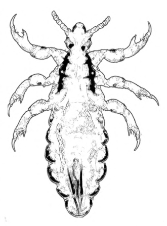

**Figure 7.1:** *Pediculus humanus capitis*, head louse (male)

| **PAn** |  | *kuCu | ‘louse’ (Blust 2002) |
| --- | --- | --- | --- |
| **PMP** |  | *kutu | ‘louse’ |
| **POc** |  | *kutu | (1) ‘louse (generic)’; (2) ‘head louse’ |
| Adm | Kaniet | *uto* | ‘louse’ |
| Adm | Lou | *kut* | ‘louse’ |
| NNG | Sio | *kutu* | ‘louse’ |
| NNG | Roinji | *ɣutu* | ‘louse’ |
| NNG | Wampur | *gur* | ‘louse’ |
| NNG | Gedaged | *ut* | ‘louse, flea, plant louse, tick’ |
| PT | Are | *kutu* | ‘louse’ |
| PT | Bwaidoga | *utu* | ‘louse’ |
| PT | Molima | *ʔutu* | ‘louse’ |
| PT | Motu | *utu* | ‘louse’ |
| MM | Vitu | *ɣutu* | ‘louse’ |
| MM | Nakanai | *utu* | ‘louse, dog flea’ |
| MM | Roviana | *ɣutu* | ‘louse’ (*ɣutu siki* ‘dog flea’) |
| SES | Bugotu | *ɣutu* | ‘louse’ |
| SES | Gela | *ɣutu* | ‘louse’ |
| SES | Lau | *ʔū* | ‘louse, flea’ |
| SES | ’Are’are | *ū* | ‘louse, flea’ |
| NCV | Mota | *wutu* | ‘louse’ |
| NCV | Raga | *gutu* | ‘generic for biting lice and sucking lice’ (*gutu-boe* ‘pig louse’, *gutu-n-manu* ‘bird louse’) |
| NCV | Tamambo | *hutu* | ‘louse’ |
| NCV | Nguna | *kūtu* | ‘louse’ |
| SV | Lenakel | *kur* | ‘louse’ |
| SV | Kwamera | *ur* | ‘louse’ |
| NCal | Nemi | *cīk* | ‘louse’ |
| NCal | Nêlêmwâ | *ciɣic* | ‘louse’ |
| NCal | Iaai | *uto* | ‘louse’ |
| Mic | Kiribatese | *uti* | ‘louse’ |
| Mic | Kosraean | *kut* | ‘louse’ |
| Fij | Rotuman | *ʔufu* | ‘louse’ |
| Fij | Wayan | *kutu* | (1) ‘head louse’; (2) ‘generic for lice and fleas’ |
| Fij | Bauan | *kutu* | ‘crab louse, flea’ |
| Pn | Tongan | *kutu* | ‘louse’ (*kutu-fisi* ‘flea’, *kutu-lotuma* ‘bedbug’) |
| Pn | Rennellese | *kutu* | ‘louse, bird louse, mite, leech, tiny insects of various kinds’ |
| Pn | Samoan | *ʔutu* | ‘louse’ |
| Pn | East Futunan | *kutu* | ‘head louse’ |
| Pn | Tikopia | *kutu* | ‘head louse’ |
| Pn | Hawaiian | *ʔuku* | ‘any small insects: louse, flea, mite’ |

### 2.2. Body lice

Because clothes did not feature strongly in the lives of Proto Oceanic speakers, who did not make use of woven cloth, I have preferred to gloss the POc reflex of PAn *tumeS ‘clothes louse’ as ‘body louse’. These creatures would no doubt have continued to exist in Proto Oceanic household items such as the woven pandanus matting generally used as sleeping mats (vol.1,80). Although the term has survived in Proto Oceanic, its PAn/PMP meaning has been restored in Niuean and East Futunan reflexes, perhaps fortuituously, through the modern advent of clothing. It seems that in societies where woven clothes were not worn, the distinction between the different kinds of lice was not significant, and either term was used in places as a generic for functionally similar creatures.

| **PAn** |  | *tumeS | ‘clothes louse’ (Blust 2002) |
| --- | --- | --- | --- |
| **PMP** |  | *tumah | ‘clothes louse’ |
| **POc** |  | *tuma | ‘body louse’ |
| NNG | Kove | *tuma* | ‘louse, flea’ |
| NNG | Numbami | *tuma* | ‘louse’ |
| PT | Gapapaiwa | *tuma* | ‘louse’ |
| PT | Ouma | *tuma* | ‘louse’ |
| PT | Suau | *tuma* | ‘louse’ |
| MM | Nakanai | *tuma* | ‘house louse, bed bug, flea’ |
| MM | Bola | *tuma* | ‘bug’ |
| MM | Nehan | *tuma(su)* | ‘bedbug’ |
| MM | Roviana | *tuma(o)* | ‘house bug’ (cf also *tuma-rere* ‘stinking black cockroach’, *tuma-rititi* ‘k.o. dragonfly’) |
| SES | Gela | *tuma* | ‘(mat-eating) moth’ |
| SES | Fagani | *(a)umʷa* | ‘louse’ |
| Pn | Niuean | *tuma* | ‘clothes louse’ |
| Pn | Tongan | *tuma* | ‘k.o.louse’ |
| Pn | East Futunan | *tuma* | ‘body or clothes louse’ |

### 2.3. Nits

| **PAn** |  | *liseqeS | ‘nit, louse egg’ (Blust 2002) |
| --- | --- | --- | --- |
| **POc** |  | *lisaq | ‘nit’[^4] |
| Adm | Mussau | *lisa* | ‘louse’ |
| Adm | Lou | *lisa* |  |
| NNG | Wogeo | *lisa* |  |
| NNG | Kove | *lare* | (vowel metathesis) |
| MM | Patpatar | *lise* |  |
| MM | Ramoaaina | *lia* |  |
| MM | Nehan | *lih* |  |
| MM | Halia | *lisa* |  |
| MM | Teop | *niha* |  |
| SES | Gela | *liha* |  |
| SES | Talise | *lisa* |  |
| SES | Kwaio | *lita* |  |
| NCV | Mota | *lisa* |  |
| NCV | Tamambo | *lisa* |  |
| NCV | Nguna | *līsa* |  |
| SV | Anejom̃ | *na-laθ* |  |
| SV | Lenakel | *(ki)lha* |  |
| SV | Kwamera | *(kʷa)resa* |  |
| SV | Sye | *ne-lis* |  |
| NCal | Nemi | *ñʰida* |  |
| Mic | Kiribatese | *rina* | (metathesis) |
| Mic | Ponapean | *c̣īl* | (metathesis) |
| Fij | Bauan | *lise* |  |
| Pn | Tongan | *liha* |  |
| Pn | Samoan | *lia* |  |
| Pn | Tikopia | *rie* | ‘nits of head lice’ |
| Pn | Māori | *riha* |  |
| Pn | Hawaiian | *lia, liha* |  |

| **PWOc** |  | *lejaŋ | ‘nit’ |
| --- | --- | --- | --- |
| NNG | Tuam | *les* |  |
| NNG | Mangap | *leze* |  |
| NNG | Yabem | *lɛsɛŋ* |  |
| PT | Dobu | *neda* |  |
| PT | Molima | *neda* |  |
| PT | Tawala | *neda* |  |
| PT | Kilivila | *lesa* |  |
| PT | Sudest | *leleji* |  |
| MM | Vitu | *leda* |  |
| MM | Bali | *ledaŋa* |  |
| MM | Meramera | *lesa* | ‘nit; louse’ |

| **PWOc** |  | *ka(R,r)oma | ‘nit’ |
| --- | --- | --- | --- |
| NNG | Labu | *alɔma(la)* |  |
| MM | Hoava | *karoma* |  |

### 2.4. Search head for lice

One POc term and one PROc term have been reconstructed with specific reference to searching for lice. Other terms with more general meaning, particularly POc *tirop, *tirop-i ‘look intently’, are sometimes used. In Kove (NNG) the expression is *ravu tuma* ‘feel for lice’ (Ann Chowning, pers. comm.).These terms indicate the likelihood of reciprocal grooming, an activity undertaken in many societies as part of social interaction.

| **PMP** |  | *tin[d]ap | ‘look intently’ (Dempwolff 1938) |
| --- | --- | --- | --- |
| **POc** |  | *tiro(p), *tirop-i- | ‘look intently, look for (lice etc.)’ |
| MM | Roviana | *ti-tiro* | ‘search for’ |
| SES | Lau | *irofi* | ‘look at fixedly, look for’ |
| SES | Kwaio | *ilo(i) (falaina)* | ‘search hair (i.e. for lice)’ (*falaina* ‘hair’) |
| SES | ’Are’are | *iro* | ‘look for, collect’ |
| SES | Sa’a | *irohi* | ‘clear the head of lice’ |
| SES | Arosi | *(ha)irōhi* | ‘look for lice in the hair’ (*ha-* ‘verbal prefix’) |
| Pn | West Futunan | *jiro(a)* | ‘look carefully, search for’ |
| Pn | Māori | *tiro* | ‘look into, examine’ |

| **POc** |  | *tapu(s), *tapus-i- | ‘seek lice’ |
| --- | --- | --- | --- |
| PT | Motu | *tahu(a)* | ‘seek, examine’ |
| PT | Gumawana | *tao* | ‘look for lice’ |
| SES | Gela | *tavuhi* | ‘seek, esp. lice in the hair’ |
| SES | Ghari | *tavu(a)* | ‘scratch, look for lice’ |
| SES | Lau | *afui* | ‘search a head for lice’ |
| NCV | Avava | *tap* | ‘pick fruit’ (John Lynch, pers. comm.) |
| NCV | Naman | *tov* | ‘pick fruit’ (John Lynch, pers. comm.) |

| **PROc** |  | *pakit, *pakit-i- | ‘search hair for lice’ |
| --- | --- | --- | --- |
| NCV | Tamambo | *vahi* | ‘groom hair, search head for lice’ |
| NCV | Nguna | *vāke* | ‘search hair for lice’ |
| Mic | Woleaian | *faxiti* | ‘search hair for lice’ |
| Mic | Mokilese | *pakit* | ‘delouse’ |

## 3. Butterflies (Order Lepidoptera = ‘scaly wings’)

A number of formally similar reconstructions for butterfly have been made above the level of POc: PAn *(qali)-beŋbeŋ, PMP *kali-mbembeŋ and PSHWNG *kalə-mbombəŋ. From the first-mentioned one would expect the regularly derived POc *kali-boboŋ. It does appear, but its reflexes are with one exception limited to the North New Guinea subgroup. The most widespread Oceanic cognate set, yielding POc *(kau)bebek, cannot be derived directly from PMP.

| **PAn** |  | *qali-beŋbeŋ | ‘butterfly’ (ACD) |
| --- | --- | --- | --- |
| **POc** |  | *[kali]bobo(ŋ) | ‘butterfly’ |
| Adm | Loniu | *popʷ(ilow)* |  |
| NNG | Gedaged | *kilibob* | ‘butterflies, a collective term’ |
| NNG | Numbami | *kaiᵐboᵐbo* |  |
| NNG | Bariai | *vovo* |  |
| NNG | Kove | *vovo* |  |
| NNG | Maleu | *na-lvovo* |  |
| NNG | Tuam | *bobo(im)* |  |
| NNG | Gitua | *bobo(koro)* |  |
| NNG | Malalamai | *vovo* |  |
| NNG | Sio | *bobo* |  |
| NNG | Bing | *kalbob* |  |
| NNG | Bilibil | *kilibob* |  |
| NNG | Megiar | *kabob* |  |
| NNG | Manam | *bo-bobe* |  |
| NNG | Bam | *ba-bob* |  |
| NNG | Wogeo | *bobo* |  |

POc *[kau]bebek has reflexes throughout almost the entire Oceanic region apart from NNG. The added *-a* in Molima, Dobu, Sewa Bay, Duau, Bwaidoga and ’Auhelawa reflects a regular process, but the labialisation of *k is unexpected.

| **POc** |  | *[kau]bebek | ‘butterfly, moth’ |
| --- | --- | --- | --- |
| Adm | Lou | *pepe* | ‘centipede’ |
| Adm | Mussau | *kau-bebe* | ‘butterfly’ |
| PT | Molima | *pepeʔʷa* | ‘butterfly’ |
| PT | Dobu | *pepekʷa* | ‘butterfly’ |
| PT | Sewa Bay | *pepekʷa* | ‘butterfly’ |
| PT | Duau | *pepekʷa* | ‘butterfly’ |
| PT | Bwaidoga | *bebewa* | ‘butterfly’ |
| PT | Gapapaiwa | *beba-beba* | ‘butterfly’ |
| PT | Ubir | *fefek* | ‘butterfly’ |
| PT | Hula | *pepe* | ‘butterfly’ |
| PT | Sinaugoro | *kau-bebe* | ‘butterfly’ |
| PT | Mekeo | *fefe* | ‘butterfly’ |
| PT | Motu | *kau-bebe* | ‘butterfly, moth’ |
| MM | Bali | *ka-bebeke* | ‘butterfly’ |
| MM | Nakanai | *bebe* | ‘butterfly’ |
| MM | Tolai | *bebe* | ‘butterfly’ |
| MM | Mono-Alu | *bebe* | ‘butterfly’ |
| SES | Lau | *bebe* | ‘butterfly, moth’ |
| SES | Sa’a | *pepe* | ‘butterfly, moth’ |
| SES | Arosi | *bebe* | ‘butterfly (generic)’ (used as first element in compound terms for partic. varieties) |
| NCV | Mota | *pepe* | ‘a yellow butterfly’ |
| NCV | Raga | *bebe* | ‘generic for butterflies and moths’ |
| NCV | Lewo | *(le)pepe* | ‘butterfly’ |
| NCV | South Efate | *(li)pep* | ‘butterfly’ |
| Mic | Kiribatese | *pʷepʷe* | ‘butterfly’ |
| Mic | Marshallese | *pʷapʷipʷ* | ‘butterfly, moth’ |
| Fij | Rotuman | *pepe* | ‘moth or butterfly of any kind’ |
| Fij | Wayan | *bēbē* | ‘butterflies and moths’ |
| Fij | Bauan | *bēbē* | ‘butterfly’ |
| Pn | Tongan | *pepe* | ‘butterfly’ |
| Pn | Pukapukan | *pepe* | ‘dragonfly’ |
| Pn | Tikopia | *pepe* | ‘butterfly, moth; gen. term for Lepidoptera’ |
| Pn | Māori | *pepe* | ‘flutter, moth’ |
| Pn | Māori | *pepepe* | ‘butterfly’ |

cf. also:

| Mic | Puluwatese | *(li)pʷekipʷek* | ‘butterfly’ (*li-* ‘nominal prefix’) |
| --- | --- | --- | --- |
| Mic | Woleaian | *(ri)ɸexiɸex* | ‘butterfly, caterpillar’ (*ri-* ‘nominal prefix’) |

One other reconstruction is restricted to Papuan Tip.

| **PPT** |  | *qara-bembem | ‘butterfly’ |
| --- | --- | --- | --- |
| PT | Ubir | *kara-bimbim* |  |
| PT | Doga | *ara-bembem* |  |
| PT | Anuki | *kara-bemem* |  |
| PT | Are | *ara-bembemta* |  |

In Western Oceanic, but with just two reflexes, I find —

| **PWOc** |  | *bebelo | ‘butterfly’ |
| --- | --- | --- | --- |
| PT | Lala | *ebebelo* |  |
| MM | Torau | *bebelo* |  |

— and in that part of MM which lies within the Northwest Solomons:

| **Proto Northwest Solomonic** |  | *pepele | ‘butterfly’ |
| --- | --- | --- | --- |
| MM | Ririo | *pepel* |  |
| MM | Sisiqa | *pe-pepele* |  |
| MM | Babatana | *pe-pepele* |  |
| MM | Nduke | *pepele* | ‘general term for butterflies and moths’ |
| MM | Roviana | *pepele* |  |
| MM | Hoava | *pepele* |  |
| MM | Vangunu | *pepele* |  |

cf. also:

| TM | Buma | *mebeli* |  |
| --- | --- | --- | --- |

What are we to make of these variations? Butterflies, like lice and flies, are commonplace, but whereas I have extremely stable cognate sets for the latter two, butterfly terms in Western Oceanic have many slightly different forms. It is as if there is wordplay, with small changes being deliberately made to a word. Was there something culturally significant about butterflies, perhaps some trace of the supernatural that the *kali-* prefix reflects, that gave rise to some taboo about the use of the normal term? Although I have examples of an association between butterflies and the supernatural in Sa’a (Ivens 1927:187), Maori (Andrew Crowe pers. comm.) and Easter Island (Steven Roger Fischer pers. comm.) I have no comparable examples from Western Oceanic. Malcolm Ross (pers. comm.) suggests an explanation involving a different kind of cultural taboo.

There is a widespread origin legend along the New Guinea north coast based on the activities of two brothers, Manub (blue dove) and Kilibob (butterfly), who, between them, ‘made their dwelling places, sun, moon and stars etc. and also the people, and gave them all their customs and usages’ (Pech 1991:81). It happens that such legends may be seen to belong to particular clans in their traditional form. Others may continue the legends but lack the right to use traditional names (Pech 1991:116). If this were the case, it would be the names, rather than the creature, which were subject to some kind of taboo. It may have been some such reason that is the explanation for the numerous variations in the WOc butterfly term. The EOc terms, however, are quite consistent, all derived from one of the WOc variations, *bebek, so evidently no longer subject to the same taboo pressures.

Although POc speakers evidently included moths and butterflies within one generic term, I have a lower-level reconstruction which is limited to moths, possibly a particular kind of moth. Samoan and Tikopia reflect *lele-fua while the Central Eastern Polynesian languages appear to have added a prefix of unclear function.

| **PNPn** |  | *[pu]lele-fua | ‘k.o. moth’ (pollex: *lele ‘fly swiftly’) |
| --- | --- | --- | --- |
| Pn | Samoan | *lele-fua* | ‘moth’ |
| Pn | Tikopia | *rere-fue* | ‘large moth’ |
| Pn | Rarotongan | *purere-ʔua* | ‘large moth sp.’ |
| Pn | Tahitian | *pūre-hua* | ‘moth’ |
| Pn | Māori | *pūrere-hua* | ‘moth’ |
| Pn | Hawaiian | *pulele-hua* | ‘butterfly, moth’ |

## 4. Mosquitoes (Order Diptera = ‘two wings’: Family Culicidae)

A POc reconstruction for ‘mosquito’, *ñamuk, is based on numerous cognates from all major subgroups, with little variation in meaning, together with a PMP antecedent. In some Papuan Tip languages reflexes form compounds to refer to a range of small flying biting insects. The PT reflexes have undergone a common sporadic vowel change, lowering of unstressed *-u* to *-o*.

A number of terms that refer to the mosquito have been reconstructed in addition to *ñamuk.

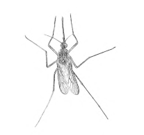

**Figure 7.2:** *Anopheles* sp., mosquito

| **PMP** |  | *ñamuk | ‘mosquito’ (Blust 2002) |
| --- | --- | --- | --- |
| **POc** |  | *ñamuk | ‘mosquito’ |
| Adm | Aua | *namu* | ‘mosquito’ |
| Adm | Seimat | *namu* | ‘mosquito’ |
| Adm | Kaniet | *ñamu* | ‘mosquito’ |
| Adm | Loniu | *ñamɔn* | ‘mosquito’ |
| NNG | Lukep (Pono) | *nam* | ‘mosquito’ |
| NNG | Kaiwa | *namuk* | ‘mosquito’ |
| NNG | Manam | *nam* | ‘mosquito’ |
| PT | Molima | *namo-namo* | ‘fly’ (*namo-kili* ‘mosquito’, *namo-kodu-kodu* ‘k.o. sandfly’) |
| PT | Bwaidoga | *nimoɣa* | ‘mosquito’ (*namo-kili-kili* ‘fruit-fly’) |
| PT | Maisin | *namoɣi* | ‘mosquito’ |
| PT | Minaveha | *namo-namo* | ‘fly (generic)’ (*namo-kina* ‘mosquito’, *vivia namo-namo* ‘wasp, small red variety’) |
| PT | Gapapaiwa | *namo-namo* | ‘fly’ (*namo-kīri* ’mosquito) |
| PT | Are | *namo-namo* | ‘housefly’ |
| PT | Motu | *namo* | ‘mosquito’ |
| PT | Sudest | *ñamo-ñamo* | ‘fruitfly’ |
| MM | Nalik | *namu* | ‘mosquito’ |
| MM | Nakanai | *lamo* | ‘mosquito’ |
| MM | Tolai | *namu* | ‘sandfly’ |
| SES | Bugotu | *ñamu* | ‘mosquito’ |
| SES | Gela | *namu* | ‘mosquito’ |
| SES | Kwaio | *namu-namu* | ‘small flying insect (generic); sandfly, gnat’ |
| SES | Arosi | *[na]namu* | ‘mosquito’ |
| TM | Buma | *muko* | ‘mosquito’ |
| NCV | Mota | *namu* | ‘mosquito’ |
| NCV | Raga | *namu* | ‘generic for mosquitoes’ |
| NCV | Paamese | *a-namu* | ‘mosquito’ |
| NCV | Nese | *namɣo* | (regular metathesis of final *-Vk) |
| SV | Sye | *yomoɣ* | ‘mosquito’ |
| SV | Anejom̃ | *n-yamʷ* | ‘mosquito’ |
| NCal | Nêlêmwâ | *nabuc* | ‘mosquito’ |
| NCal | Nemi | *naguk* | ‘mosquito’ |
| Mic | Marshallese | *namʷ* | ‘mosquito’ |
| Mic | Woleaian | *ramʷu* | ‘mosquito’ |
| Mic | Ulithian | *lamʷo* | ‘mosquito’ |
| Fij | Bauan | *namu* | ‘mosquito’ |
| Fij | Wayan | *am* | ‘mosquito’ |
| Pn | Tongan | *namu* | ‘mosquito’ |
| Pn | Tahitian | *namu* | ‘mosquito’ |
| Pn | Māori | *namu* | ‘sandfly’ |

The following reconstruction shares the same second syllable as *ñamuk ‘mosquito’. Both *ñamuk and *simuk evidently referred to ‘mosquito’ in WOc, although *simuk may have had a broader semantic range than *ñamuk, its reflexes at times referring to other small biting flies. Southeast Solomonic terms reflect PSES *simi rather than †*simu. (Maringe *si-simi* is evidently borrowed from a neighbouring SES language). Reflexes of *simuk are not found in subgroups east of the Solomons.

| **POc** |  | *simuk | ‘mosquito, small biting fly’ |
| --- | --- | --- | --- |
| NNG | Tuam | *sum* | ‘mosquito’ |
| NNG | Mato | *simak* | ‘sandfly’ |
| NNG | Labu | *sumu(si)* | ‘mosquito’ |
| PT | Wedau | *imo(kini)* | ‘mosquito’ (*kini* ‘to sting’) |
| PT | Tawala | *himo(kini)* | ‘mosquito’ |
| PT | Tawala | *himo-himo(kini)* | ‘sandfly’ |
| PT | Dawawa | *simo(kin)* | ‘mosquito’ |
| MM | Mono-Alu | *simuʔu* | ‘midge’ |
| MM | Varisi | *simu-simu* | ‘midge’ |
| MM | Avaso | *simuku* | ‘mosquito’ |
| MM | Maringe | *si-simi* | ‘housefly’ |
| SES | Lau | *simi* | ‘sandfly’ |
| SES | Baegu | *si-simi* | ‘midge’ |
| SES | Longgu | *simi* | ‘mosquito’ |
| SES | Kwai | *simi(sakʷalo)* | ‘mosquito’ |
| SES | Kwaio | *simi* | ‘fly, sandfly’ |
| SES | Kwaio | *simi(lakʷalo)* | ‘mosquito’ |
| SES | Dori’o | *simi(lakʷalo)* | ‘midge’ |
| SES | Dori’o | *simi(ni-ōne)* | ‘mosquito; sandfly’ |
| SES | ’Are’are | *sime* | ‘mosquito’ |
| SES | Sa’a | *sime* | ‘mosquito’ |

Another term, POc *ma-kini(t), is also reconstructable, with reflexes thar refer to ‘mosquito’ in Western Oceanic, but in Remote Oceanic rather to the state of being stung. As a literal translation of a form of the verb *kini-t, ‘to pinch’, *ma-kini(t) means ‘to get pinched’, i.e. ‘get stung’. The languages in which reflexes of *ma-kini(t) are listed have all lost POc final consonants, and putative final *-t is reconstructed on the basis of etymology. In languages such as (PT) Gumawana, the meaning of the verb *gini* includes ‘to puncture, spear, inject, sting’. Reflexes of *kini-t appear frequently in PT languages as the second element in compound terms referring to biting insects. (See also POc *simuk above.)

| **POc** |  | *ma-kini(t) | ‘mosquito’ |
| --- | --- | --- | --- |
| NNG | Bariai | *makin-kin* | ‘mosquito’ |
| NNG | Kove | *makini-kini* | ‘mosquito’ |
| MM | Nakanai | *makili-kili* | ‘black gnats, sandflies’ |
| MM | Bali | *makini-kini* | ‘mosquito’ |
| MM | Bulu | *makini-kini* | ‘mosquito’ |
| **PROc** |  | *makini | ‘to be stung’ |
| NCV | Nguna | *makini-kini* | ‘itchy’ |
| Pn | Samoan | *maʔini* | ‘to sting, to smart’ |
| Pn | Tongan | *makini* | ‘to have a pricking or tingling sensation like pins and needles’ (also *makini-kini* implying duration) |

cf. also:

| Pn | Tikopia | *kini-kini* | ‘insect, small brown, predatory on man, in houses (? flea)’ |
| --- | --- | --- | --- |

A tendency to identify small buzzing and biting insects with nasal-initial terms and frequent reduplication is noted with *ñamuk as well as POc *ŋiŋi(ŋ) and PWOc *ŋati-ŋati below, and is apparent also in the terms for sandfly/midge/gnat in the following section (POc *niku-niku, *nonok, *ŋi(s,j)i). Most are onomatopaeic, using *n*, *ñ* and *ŋ* almost interchangeably, making it difficult to trace cognate forms.

| **PMP** |  | *ŋiŋ | ‘buzz, hum’ (ACD) |
| --- | --- | --- | --- |
| **POc** |  | *ŋiŋi(ŋ) | (1) ‘buzz as a mosquito’; (2) ‘mosquito’ (onomatopoeic) |
| NNG | Bing | *ŋiŋ* | ‘mosquito’ |
| SES | Gela | *ŋiŋi* | ‘buzz as a mosquito’ |
| SES | Talise | *ŋi* | ‘midge’ |
| SES | Birao | *ŋi* | ‘midge’ |
| SES | Tolo | *ŋi* | ‘mosquito’ |
| Fij | Bauan | *ŋīŋī* | ‘buzz as a mosquito’ |

| **PWOc** |  | *ŋati-ŋati | ‘mosquito’ |
| --- | --- | --- | --- |
| NNG | Mapos Buang | *ŋat-ŋat* | ‘mosquito’ |
| PT | Gapapaiwa | *nasi-nasi* | ‘small brown fly’ |
| MM | Tabar | *ŋati-ŋati* | ‘mosquito’ |
| MM | Lihir | *ŋet-ŋet* | ‘mosquito’ |
| MM | Madak | *ŋit* | ‘mosquito’ |
| MM | Ramoaaina | *ŋat-ŋat* | ‘sandfly’ |
| MM | Patpatar | *ŋati-ŋat* | ‘mosquito’ |
| MM | Minigir | *ŋati-ŋati* | ‘mosquito’ |
| MM | Tolai | *ŋati-ŋat* | ‘mosquito’ |
| MM | Nehan | *nat-nat* | ‘mosquito’ |

## 5. Sandflies, midges, gnats (Order Diptera: Families Chironomidae (non-biting), Ceratopogonidae, Psychodidae, Simuliidae (biting); Families Drosophilidae, Tephritidae (fruitflies))

Cognates in the following sets refer to a range of very small flying biting insects. Vagueness of identity may be due to the fact that speakers have no real need to distinguish these insects more precisely.

POc *niku-niku from PMP *nik-nik rather than the expected †*ninik may simply be another example of the playful variation prevalent in some insect terms.

| **PMP** |  | *nik-nik, *ñik-ñik | ‘tiny biting insect: gnat, sandfly, fruitfly’ (ACD) |
| --- | --- | --- | --- |
| **POc** |  | *niku-niku | ‘small biting fly’ |
| PT | Bwaidoga | *niku-niku* | ‘small fly that bites (like sandfly)’ |
| MM | Vitu | *niki* | ‘mosquito’ |
| MM | Konomala | *nuk-nuk* | ‘mosquito’ |
| MM | Tolai | *nuku-nuku* | ‘very small fly’ |
| MM | Roviana | *niku-niku* | ‘k.o. sandfly whose bite is painful’ |
| MM | Hoava | *niku-niku* | ‘midge’ |
| MM | Vangunu | *niku-niku* | ‘midge’ |

Polynesian reflexes of *nonok ‘sandfly, midge’ appear to refer to fruitflies and perhaps other small non-biting flies. The Cristobal-Malaitan terms reflect PCM *nono(i)tasi, literally ‘fly of salt water’.

| **PMP** |  | *nek-nek | ‘gnat, sandfly, fruit fly’ (ACD) |
| --- | --- | --- | --- |
| **POc** |  | *nonok | ‘sandfly, midge’ |
| Adm | Lou | *(tip)non* | ‘sandfly,mosquito’ |
| Adm | Baluan | *(liplip)non* | ‘sandfly’ |
| MM | Mono-Alu | *nono* | ‘mosquito’ |
| MM | Nduke | *nonoɣo* | ‘mosquito’ |
| SES | Gela | *nonoke* | ‘ko. sandfly on the shore’ |
| SES | Baegu | *nono(āsi)* | ‘sandfly’ |
| SES | ’Are’are | *nono(asi)* | ‘small stinging midge; gnat; sandfly’ |
| SES | Sa’a | *nono(asi)* | ‘midge, gnat’ |
| SES | Arosi | *nono* | ‘fly’ |
| SES | Arosi | *nono(iasi)* | ‘sandfly’ |
| SES | Arosi | *(ʔarai)nono* | ‘mosquito’ (*ʔaraʔi* ‘to bite, sting’) |
| SES | Fagani | *nana(osi)* | ‘sandfly’ (vowel metathesis) |
| NCV | Mota | *nono* | ‘a small beetle that comes on decaying fruit’ |
| NCV | Lewo | *ne-nono* | ‘sandfly, midge, fruitfly’ |
| NCV | Uripiv | *nunu* | ‘midge’ |
| Pn | Niuean | *nono* | ‘small beetle’ |
| Pn | Tongan | *nono* | ‘fruitfly’ |
| Pn | Rennellese | *nono* | ‘k.o. small fly found on rotten bananas’ |
| Pn | Samoan | *nono* | ‘white ant when winged’ |
| Pn | Tikopia | *nono* | ‘fruitfly’ |
| Pn | Tuvalu | *nono* | ‘small flying insect’ |
| Pn | East Uvean | *nono* | ‘small flying insect’ |

The next reconstruction is reflected mainly in compound terms which include a range of unidentified elements.

| **POc** |  | *ŋi(s,j)i | ‘sandfly’ |
| --- | --- | --- | --- |
| Adm | Mussau | *(kala)ŋisi* | ‘sandfly’ |
| NNG | Malai | *(maraŋ)ŋis-ŋis* | ‘sandfly’ |
| NNG | Lukep (Pono) | *(bara)ŋis-ŋis* | ‘sandfly’ |
| NNG | Singorakai | *(mala)ŋis* | ‘sandfly’ |
| NNG | Tami | *siŋi-siŋ* | ‘firefly’ (metathesis) |
| NNG | Wab | *ŋis* | ‘sandfly’ |
| NNG | Bing | *(ramaŋas)ŋis* | ‘sandfly’ |
| NNG | Mindiri | *(bɔrɔ)ŋis* | ‘sandfly’ |
| NNG | Manam | *(mara)ŋizi-ŋizi* | ‘k.o. gnat, small’ |
| SES | West Guadalcanal | *ŋiju* | ‘sandfly’ |

| **PWOc** |  | *ki(r,R)i-ki(r,R)i | ‘sandfly’ |
| --- | --- | --- | --- |
| PT | Gapapaiwa | *kiri-kiri* |  |
| PT | Ubir | *ire* |  |
| PT | Dobu | *(dagʷa)kili-kili* |  |
| MM | Maringe | *gri-gri* |  |

## 6. Flies (Order Diptera: Families Muscidae (houseflies, bluebottles), Tabanidae (horseflies), Bibionidae (Marchflies))

### 6.1. Flies (generic); houseflies

Blust (2002) has reconstructed both PMP *lalej ‘housefly’ and PMP *laŋaw ‘botfly, bluebottle’. The latter became in POc the generic term for flies, with reflexes often referring specifically to the common housefly.

Reflexes of POc *laŋo ‘fly’ are both numerous and widespread, occurring in all major subgroups. In a number of languages including Lou (Adm), Gela (SES) and Hawaiian (Pn), the term is used in compounds as first element, referring to a range of flies (housefly, blowfly, horsefly, March fly, bluebottle fly etc.).

| **PMP** |  | *laŋaw | ‘botfly, bluebottle’ (Blust 2002) |
| --- | --- | --- | --- |
| **POc** |  | *laŋo | ‘fly’ |
| Adm | Mussau | *laŋo* | ‘housefly’ |
| Adm | Lou | *laŋ-laŋ(a)* | ‘fly, flying insect’ |
| Adm | Lou | *laŋ(et)* | ‘housefly’ |
| Adm | Lou | *laŋ-laŋa-n palawa* | ‘honey bee’ |
| Adm | Lou | *laŋ-laŋ ŋara* | ‘bluebottle, horsefly, March fly’ |
| NNG | Tami | *laŋo-laŋ* | ‘fly’ |
| NNG | Kove | *laŋo-laŋo* | ‘fly’ |
| NNG | Kove | *laŋo-vihi* | ‘blowfly, big, blue, noisy, bites and stinks’ |
| NNG | Sengseng | *laŋ* | ‘fly’ |
| NNG | Sengseng | *laij-i-yuyu* | ‘hornet with papery nest’ |
| NNG | Sengseng | *laŋ-oŋoŋ* | ‘insect that makes holes in wood’ |
| PT | Motu | *lao* | ‘fly’ |
| PT | Lala | *nalo* | ‘k.o. fly’ (metathesis) |
| MM | Tabar | *raŋo* | ‘fly’ |
| MM | Vitu | *laŋo* | ‘fly’ |
| MM | Nehan | *laŋo* | ‘fly’ |
| SES | Gela | *laŋo* | ‘fly (generic)’ (first element in many binomial fly terms) |
| SES | Sa’a | *laŋo* | ‘bluebottle fly’ |
| SES | Arosi | *raŋo* | ‘fly’ |
| NCV | Mota | *laŋo* | ‘bluebottle fly’ |
| NCV | Raga | *laŋo* | ‘generic for flies’ |
| NCV | Paamese | *a-laŋo* | ‘fly’ |
| SV | Sye | *(u)laŋ* | ‘a fly’ |
| SV | Lenakel | *(k)iaŋ* | ‘a fly’ |
| SV | Southwest Tanna | *(e)laŋ* | ‘a fly’ |
| NCal | Nemi | *nen* | ‘fly’ |
| NCal | Jawe | *nen* | ‘fly’ |
| Mic | Kiribatese | *naŋo* | ‘fly, blowfly’ |
| Mic | Woleaian | *raŋo* | ‘fly’ |
| Mic | Sonsorolese | *rāŋo* | ‘fly’ |
| Fij | Rotuman | *laŋo* | ‘fly’ |
| Fij | Bauan | *laŋo* | ‘fly’ |
| Pn | Samoan | *laŋo* | ‘fly’ |
| Pn | Tikopia | *raŋo* | ‘fly’ |
| Pn | Māori | *raŋo* | ‘fly’ (eastern dialect) |
| Pn | Hawaiian | *nalo* | ‘common house fly’ (Used as first element in compounds for hornet, wasp, bee, bluebottle etc.; metathesis) |

### 6.2. Horseflies and March flies

Members of the horsefly and March fly families suck the blood of mammals, inflicting a painful bite. Few terms have been collected, and no reconstructions have been possible.

## 7. Dragonflies and damselflies (Order Odonata = ‘flies with teeth’)

Dragonflies and damselflies are arguably the most acomplished aerialists in the animal kingdom. Swift and agile, they can reverse direction in midair within one body length, hover with ease and fly backwards. They copulate in the air, typically over a body of fresh water, where the female lays her eggs. Although cognate sets have been elusive, a remarkable consistency of meaning has emerged in descriptive compounds meaning literally ‘copulate’ + ‘water’, from terms in SE New Britain to the Solomons to Fiji. Terms referring to copulation have evidently been replaced by euphemisms in many languages. Lack of cognacy in the terms for water is due to the tendency in some languages to generalise terms originally referring specifically to fresh water, rain, river, pond and so on. For instance, the second element in the Pendau (central Sulawesi) term for a dragonfly, *tuntu/rano*, translates literally as ‘lake’ (Phil Quick pers. comm.). POc *waiR ‘water’ is attested in the two following (non-cognate) sets by terms from SES, NCV and Fiji.

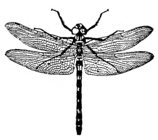

**Figure 7.3:** Dragonfly

| NNG | Poeng | *roro-me* | ‘dragonfly’ (*roro* ‘copulate’, *me* ‘water’) |
| --- | --- | --- | --- |
| SES | Gela | *hita-hita-beti* | ‘dragonfly’ (*hito* ‘to cohabit’, *beti* ‘water, stream’) |
| SES | Arosi | *ʔani-wai* | ‘dragonfly’ (*ʔani* ‘fornicate’, *wai* ‘water’) |
| Mic | Trukese | *nifēfēcon* | ‘dragonfly’ (‘the one that copulates with water’; Davis 1999) |
| Fij | Wayan | *dulu-dulu-wai* | ‘dragonfly’ (*dulu* ‘copulate’, *wai* ‘water’) |
| Fij | Bauan | *ðai-ðai-wai* | ‘dragonfly’ (*ðai* ‘copulate’, *wai* ‘water’) |

Other compounds retain the water connection, but vary the verbal concept.

| PT | Sudest | *wawa-eᵐba* | ‘dragonfly’ (*wawa* ?, *ᵐbʷa* ‘water’) |
| --- | --- | --- | --- |
| SES | Gela | *gito-beti* | ‘dragonfly’ (‘steal water’) |
| SES | Tolo | *ici-kolo* | ‘dragonfly’ (ici ?, kolo ‘water’) |
| SES | Lau | *nalu-kafo* | ‘dragonfly’ (‘scoop up water’) |
| SES | Lau | *tatara kafo* | ‘dragonfly’ (‘skim water’) |
| SES | Longgu | *tatara-wai* | ‘large dragonfly with tail like a helicopter’ (lit ‘skim water’) |
| SES | Sa’a | *tātara-wai* | ‘dragonfly’ (‘skim water’) |
| SES | Arosi | *tātā-wai* | ‘dragonfly’ (‘skim water’) |
| SES | ’Are’are | *tatara-wa* | ‘dragonfly’ (‘skim water’) |
| NCV | Mota | *roro-pei* | ‘dragonfly’ (*roro* ‘sink’, *pei* ‘water’) |
| NCV | Paamese | *menmen-oai* | ‘dragonfly’ (*men-men* cf. *munmun* ‘drink’, *oai* ‘water’) |
| NCV | Southeast Ambrym | *munmun-oi* | ‘dragonfly’ (‘drink water’) |

Samoan retains the skimming element in *seʔe-mū* ‘dragonfly’ (*seʔe* ‘glide’, *mū* ‘flying insect’).

The Rennellese describe it as a sailing insect: *manu-manu hogau* (*hogau* ‘sailor, ocean voyager’).

There are isolated instances of dragonflies being used in sorcery, as a means of causing death in Kiribati (Rosemary Grimble 1972:26-27) and to facilitate theft in Tahiti (Henry 1971:391), but rather than reflecting something specific about the role of dragonflies in POc times, this is probably no more than an indication that certain insects were commonly regarded as agents of the gods and spirits.

## 8. Bees (Order Hymenoptera = ‘membrane wings’: Super Family Apoidea)

The following reconstruction rests on a pair of cognates from different primary subgroups.

| **POc** |  | *kororo | ‘bee’ |
| --- | --- | --- | --- |
| Adm | Lou | *koror* | ‘bee (generic)’ |
| MM | Teop | *kororo* | ‘honey-bee/honey/(ear wax)’ |

cf. also:

| PT | Sinaugoro | *kororo* | ‘cricket’ |
| --- | --- | --- | --- |

Although the following reconstruction bears some resemblance to PMP *(n,ñ)ik-(n,ñ)ik, ‘tiny biting insect: gnat, sandfly, fruitfly’ (§5), it is lacking a final consonant and may simply have been generated independently on onomatopoeic grounds. The initial *ŋ-* of the Lau and Sa’a cognates is a common variation on *n-* and *ñ-* that occurs in terms for buzzing insects.

| **POc** |  | *(n,ñ)i(n,ñ)i | ‘bee, buzzing insect’ |
| --- | --- | --- | --- |
| Adm | Seimat | *nini* | ‘bee’ |
| NNG | Kela | *nini* | ‘mosquito’ |
| NNG | Sio | *ni* | ‘mosquito’ |
| NNG | Labu | *nene(ᵑgʷa)* | ‘fly (insect)’ |
| NNG | Takia | *nini* | ‘bee, wasp (generic)’ |
| SES | ’Are’are | *nini(sua)* | ‘a bee which makes its nest in the ground and in trees’ (*sua* ‘to burrow’) |
| SES | Lau | *ŋiŋi(dua)* | ‘bee’ |
| SES | Sa’a | *ŋiŋi(due)* | ‘native bee’ |

## 9. Wasps (Order Hymenoptera): Families Ichneumonidae, Vespidae (paper wasp), Sphecidae (mud-dauber wasp, mason wasp)

I have been unable to identify a particular species that can be identified by POc *pupuk. It may be a name given to any wasp-like insect that infests wood.

| **PMP** |  | *bukbuk | ‘weevil that infests wood, bamboo, and rice; dust produced by the boring of this insect; tooth decay, dental caries’ (ACD) [^5] |
| --- | --- | --- | --- |
| **POc** |  | *pupuk | ‘k.o. borer wasp or bee that infests wood and bamboo’ |
| NNG | Gedaged | *fuf* | ‘wood-borer’ |
| PT | Sudest | *vuvu* | ‘sugarcane borer’ |
| PT | Gapapaiwa | *vuvua* | ‘bee type; carpenter bee’ |
| PT | Molima | *wuwuwuva* | ‘borer wasp’ |
| MM | Patpatar | *huh* | ‘borer insect; wood that has been bored by wood-borers’ |
| MM | Nakanai | *vuvu* | ‘wasp and wasp-like insects’ |
| MM | Tolai | *pupuka* | ‘weevil; dust from weevil-eaten bamboos in house roof’ |
| MM | Nduke | *vuvu* | ‘black insect that eats wood’ |
| MM | Maringe | *fufu* | ‘bamboo borer’ |
| SES | Gela | *vuvu* | ‘a worm that bores into wood’ |
| SES | Bugotu | *vūvū* | ‘mason wasp’ |
| SES | Tolo | *vuvu* | ‘k.o. wasp which bores through wood’ |
| SES | Longgu | *vuvu(i)* | ‘a type of black wasp, digs in the ground, painful if it stings you’ |
| SES | Lau | *fufu* | ‘mason wasp’ |
| Pn | Niuean | *(laŋo) fufu* | ‘mason wasp’ |
| Pn | Tahitian | *huhu* | ‘xylocope or carpenter bee, large Hymenopterous insect, black, attacks wood’ |
| Pn | Māori | *huhu* | ‘larva of beetle sp., edible grub’ |
| Pn | Hawaiian | *huhu* | ‘wood-boring insect, worm-eaten’ |
| Pn | Marquesan | *huhu* | ‘white wood-eating worm’ |

cf. also:

| PT | Minaveha | *vuvu(ha)* | ‘bee, small black variety that bores holes in wood’ |
| --- | --- | --- | --- |
| MM | Nakanai | *vuvu(li)* | ‘k.o. stinging worm which is painful’ (reflects †*pupuni) |
| MM | Roviana | *vuvu(nu)* | ‘wood-eating worm’ (reflects *pupun_ rather than _*pupuk) |
| NCV | Raga | *huhu (gai)* | ‘generic for wood-boring beetle larvae’ (expect *vuvu*) |
| NCV | Raga | *huhu (lua)* | ‘bee or wasp, hairy body, large head, painful sting’ |

The next reconstruction, POc *bubu ‘k.o. wasp’, may simply be a variant of POc *pupuk.

| **POc** |  | *bubu | ‘k.o. wasp’ |
| --- | --- | --- | --- |
| NNG | Adzera | *(wa)ᵐpup* | ‘hornet’ |
| NNG | Kove | *vuvuvu* | ‘wasp, kills spiders’ |
| PT | Motu | *bubu* | ‘an insect like a wild bee that destroys timber’ |
| PT | Lala | *bubu* | ‘hole-borer wasp’ |
| MM | Roviana | *bubu* | ‘Buzzer wasp (*Odynerus superbum*)’ |
| MM | Nduke | *bubu* | ‘black wasp, lives in the ground’ |
| MM | Mono-Alu | *(si)bubū* | ‘wasp’ |
| SES | Sa’a | *pū* | ‘mason bee, wasp’ |
| SES | ’Are’are | *pū* | ‘wasp’ |

cf. also:

| NNG | Gitua | *bubu(la)* | ‘housefly, mosquito’ |
| --- | --- | --- | --- |
| SES | Sa’a | *pupu(oro)* | ‘an insect which digs up the ground and leaves a track’ (*oro* ‘stoop down’) |
| SES | Arosi | *buburu(mʷago)* | ‘mason bee, v large variety’ (*mʷago* ‘earth, soil, brown?’. Also *totora mʷago* ‘mason bee’) |
| SES | Arosi | *buburu(atoā)* | ‘k.o. cricket’ (*atoā* ‘noon’) |
| Pn | Tikopia | *pupu(matau)* | ‘dragonfly’ (*matau* ‘fishhook’?; trad, embodiment of spirit) |

I am unable to account for the existence of two very similar POc reconstructions for ‘wasp’, *manipo and *(n,ñ)i(n,ñ)ipo, although presumably they are contrasted with *pupuk/*bubu. Nor can they be divided according to their subgroups; reflexes of both appear in the Admiralties and in the Southeast Solomons. Wandamen (SHWNG) *anibar* ‘wasp/bee’ may be a non-Oceanic cognate. A third group reflects Proto Central Papuan *naniɣo. It seems that here we have yet another example of wordplay. It is difficult to know whether the resemblance between *(n,ñ)i(n,ñ)ipo ‘wasp’ below and *(n,ñ)i(n,ñ)i ‘bee, buzzing insect’ (§8) arose by chance or reflects common ancestry in some way.

| **POc** |  | *mañipo | ‘k.o. wasp’ |
| --- | --- | --- | --- |
| Adm | Loniu | *menih* | ‘large black bee; k.o. deep water seaweed which stings’ (exp *meñipo*) |
| PT | Iduna | *manibo* | ‘blue insect, perhaps k.o. mud wasp’ |
| SES | Bugotu | *mañivo* | ‘wasp’ |
| SES | Tolo | *manivo* | ‘wasp’ |
| SES | Lengo | *manivo* | ‘wasp’ |
| SES | Arosi | *ma-maniho* | ‘hornet’ |

cf. also:

| NNG | Yabem | *baniʔ* | ‘generic for wasps, hornets’ |
| --- | --- | --- | --- |

| **POc** |  | *(n,ñ)i(n,ñ)ipo | ‘k.o. wasp’ |
| --- | --- | --- | --- |
| Adm | Drehet | *ninih* |  |
| SES | Longgu | *ninivoi* |  |
| SES | Sa’a | *niniho* | ‘hornet’ |

cf. also:

| NNG | Manam | *niniko* | ‘wasp’ |
| --- | --- | --- | --- |
|  | Proto Central Papuan | *naniɣo | ‘wasp’ |
| PT | Sinaugoro | *naniɣo* | ‘small black and red wasp’ |
| PT | Motu | *naniɣo* | ‘k.o. manu manu. hornet’ |
| PT | Lala | *naniʔo* | ‘wasp’ |

In the next set we find the same lowering of an unstressed vowel from /*-u*/ to /*-o*/ in Papuan Tip languages that was noted in reflexes of POc *ñamuk (§4).

| **PWOc** |  | *gumu | ‘k.o. wasp’ |
| --- | --- | --- | --- |
| PT | Dobu | *gumo* | ‘paper wasp’ |
| PT | Sariba | *gumo* | ‘wasp, bee’ |
| PT | Muyuw | *gum* | ‘wasp, hornet’ |
| PT | Molima | *gumo* | ‘wasp’ |
| PT | Tawala | *gumo* | ‘wasp’ |
| PT | Nimoa | *gumo* | ‘black wasp’ |
| MM | Maringe | *gu-ɣumhu* | ‘mud wasp’ |

## 10. Ants (Order Hymenoptera: Family Formicidae)

Although sources for a number of languages give a term for ants in general, I cannot reconstruct a POc generic. It is likely that the dominant ant species varies from place to place, and that the term for that species has become the generic term in that area. In Yabem (NNG), for instance, the generic term is *lêsêʔ*, in Sudest (PT) it is *vwara-vwara*, in Vitu (MM) *duri-duri*, and in Kwaio (SES), *ta-galo*. In Wayan Fijian *kadi* (from POc *kadik ‘stinging black ant’) has become the generic. In Niue and Tonga, *lō* (from POc *loRo ‘large red stinging ant’) is the generic form. However, a number of POc reconstructions can be made for ant taxa.

| **POc** |  | *kadik | ‘stinging black ant’ |
| --- | --- | --- | --- |
| Adm | Nyindrou | *karak* | ‘ant’ (Tryon 1995) |
| NNG | Kaulong | *keh-keh* | ‘(?) (red) ant’ |
| MM | Bulu | *kadi* | ‘stinging black ant’ |
| MM | Tolai | *kədik* | ‘black ant’ (*kərəkum* ‘large red ant’) |
| MM | Nehan | *kadik* | ‘tree ant’ |
| MM | Simbo | *kadiki* | ‘black ant’ |
| SES | Gela | *ɣadi* | ‘k.o. black ant, bulldog ant’ |
| SES | Lengo | *ɣadi* | ‘black ant’ |
| SES | Longgu | *hadi* | ‘black ant that bites’ (possibly a borrowing from Malango) |
| SES | Lau | *kadi* | ‘bulldog ant’ |
| SES | Kwaio | *(kā)kadi* | ‘stinging black ant’ |
| NCV | Mwotlap | *ɣen* | ‘big stinging black ant’ |
| NCV | Nguna | *kādi* | ‘black biting ant’ |
| NCV | Ambae | *gadi* | ‘fire ant’ |
| NCV | Nese | *na-ɣajɣe* | ‘fire ant’ (regular final *-Vk metathesis) |
| SV | Ura | *(w)asek* | ‘small stinging black ant’ |
| SV | Lenakel | *kasək* | ‘soldier ant’ |
| SV | Anejom̃ | *n-ɣas* | ‘fire ant’ |
| Mic | Woleaian | *(u)xeṣi* | ‘k.o. black ant’ |
| Mic | Carolinian | *(wu)xeṣ* | ‘large black ant with a painful stinging bite, makes its nest near rotting trees’ |
| Mic | Kosraean | *kaṣ(kin)* | ‘k.o. ant’ |
| Mic | Ponapean | *kāc̣* | ‘ant’ |
| Fij | Wayan | *kadi* | ‘generic for ants; large ants’ |
| Fij | Bauan | *kadi* | ‘large black ant, stings’ |

Rufus Pech refers to the stinging red ant of the north New Guinea coast (*lol* in Tami) in the following way: ‘This is perhaps the most enterprising and obviously ubiquitous species of ant in the Melanesian lowlands. They build huge nests in trees by drawing and sticking together bunches of leaves, are carnivorous, and defend their territory ferociously.’ (Pech 1991:91). POc *loRo probably referred to this group of ants although witnesses in Eastern Oceanic have a wider range of reference.

| **PMP** |  | *loRo | ‘red tree ant’[^6] |
| --- | --- | --- | --- |
| **POc** |  | *loRo | ‘large stinging red ant’ |
| Adm | Mussau | *loa* | ‘red tree ant’ |
| NNG | Tami | *lol* | ‘stinging red ant’ |
| MM | Vitu | *loro* | ‘large red stinging ant’ |
| MM | Nakanai | *lolo* | ‘large red ant’ |
| MM | Tabar | *ror* | ‘red ants’ |
| MM | Tangga | *lo* | ‘large sugar ants’ |
| SES | Gela | *lolo* | ‘small black ant’ |
| SES | Longgu | *lolo* | ‘a small ant’ |
| SES | Lau | *lolo* | ‘k.o. ant’ |
| SES | Kwaio | *lolo* | ‘ant’ |
| SES | Sa’a | *lolo* | ‘red sugar ant’ |
| Fij | Rotuman | *roro* | ‘fruit fly’ |
| Fij | Bauan | *lō* | ‘small black ant’ |
| Fij | Bauan | *lolo* | ‘small ant’ |
| Pn | Niuean | *lō* | ‘ant (generic)’ |
| Pn | Tongan | *lō* | ‘ant (generic)’: kinds: *lō hina* (white ant), *lō kula* (red ant?), *lō ʔuli* (black), *loʔata* (see below)’ |
| Pn | Tikopia | *ro* | ‘ant, of various kinds’ |
| Pn | Tahitian | *rō* | ‘ant’ |
| Pn | Māori | *rō* | ‘ant, stick insect, mantis’ |
| Pn | Hawaiian | *lō* | ‘black insect, earwig’ |

cf. also:

| Adm | Lou | *lolɛ* | ‘small black sugar ant’ |
| --- | --- | --- | --- |

The next set is possibly a compound form of the above.

| **PPn** |  | *lō-qata | ‘large ant’ (PPn *qata ‘image, likeness’) |
| --- | --- | --- | --- |
| Pn | Tongan | *lōʔata* | ‘k.o. black ant w painful bite’ |
| Pn | Samoan | *lōata* | ‘k.o. large black ant’ |
| Pn | Nanumean | *loata* | ‘large ant’ |

The three reconstructions which follow, POc *drui ‘ant’, POc *[driu]driu ‘small red or brown ants’ and PWOc *didi ‘small ant’ may all be variants of the same etymon.

| **POc** |  | *drui | ‘ant’ |
| --- | --- | --- | --- |
| MM | Kandas | *dui-dui* | ‘centipede’ |
| MM | Siar | *dui* | ‘centipede’ |
| MM | Simbo | *dui* | ‘ant’ (any ant?) |
| MM | Nduke | *dui* | ‘small black ant, found in gardens’ |
| MM | Roviana | *dui* | ‘small ant’ |
| SES | Tolo | *(koko)dui* | ‘reddish-brown ant’ |
| SES | Ghari | *dui-dui* | ‘grey middle-sized ant’ |
| SES | Lau | *dudui* | ‘k.o. large yellow ant in trees’ |
| SES | Kwaio | *dui-dui* | ‘vinegar ant’ |
| SES | To’aba’ita | *dūdui* | ‘fairly big reddish ant, stings’ |
| NCV | Nokuku | *ʔuʔui* | ‘ant’ |
| NCV | Nduindui | *dui-dui* | ‘ant’ |

cf. also:

| MM | Vitu | *duri-duri* | ‘generic for ants’ |
| --- | --- | --- | --- |

| **POc** |  | *[driu]driu | ‘small red or brown ants’ |
| --- | --- | --- | --- |
| MM | Sursurunga | *diu* | ‘centipede’ |
| SES | Arosi | *diu-diu, di-diu* | ‘k.o. small brown ant’ |
| NCV | Mota | *ni-niu* | ‘small red ant’ |
| NCV | Ambae | *di-diu* | ‘ant’ |
| NCV | Tangoa | *ri-riu* | ‘red ant’ |
| NCV | Tamambo | *diu-diu* | ‘small sugar ants; general term for red and brown ants, just a nuisance with food’ |
| Fij | Wayan | *(kā)driu-driu* | ‘very small ants’ |

Given that all terms in the following set except Nduke are binomials, *didi may have been a generic for ‘ant’.

| **PWOc** |  | *didi | ‘small ant’ |
| --- | --- | --- | --- |
| NNG | Labu | *titi(nalo)* | ‘ant’ (*nalo* ‘small’) |
| PT | Dobu | *didi(yauyau)* | ‘ant’ (*yau* ‘number, to increase in number’) |
| PT | Sinaugoro | *didi(rima)* | ‘small black ants’ |
| PT | Sinaugoro | *riri(ka)* | ‘sugar ants’ |
| MM | Tolai | *(kara)didi* | ‘larvae of the red ant, used as food’ |
| MM | Nduke | *didi* | ‘wood-borer’ |

The next set consists of possibly related items, but there are too many irregularities to permit a POc reconstruction.

| NNG | Vehes | *kakak* | ‘ant’ |
| --- | --- | --- | --- |
| NNG | Mapos Buang | *kakok* | ‘ant’ |
| NNG | Kumaru Mumeng | *kakok* | ‘ant’ |
| NNG | Patep | *kekeak* | ‘ant’ |
| NNG | Zenag | *kkewa* | ‘ant’ |
| MM | Tolai | *kakakau* | ‘small black ant’ |
| SES | Arosi | *ʔaʔaki* | ‘large black ant, bulldog ant, w painful bite’ |

Although the following terms for ‘ant’ appear to be related (reflecting POc *kal(a,o)) all except Marshallese carry additional unrelated morphemes which cannot be accounted for.

| Adm | Loniu | *kalɔ(n)* | ‘ant’ |
| --- | --- | --- | --- |
| PT | Sariba | *kalakala-pʷasipʷasi* | ‘black ants’ |
| MM | Teop | *ano(hi)* | ‘ant’ |
| SES | ’Are’are | *(ta)karo* | ‘small black ant’ |
| NCV | Nguna | *(ma)kāla* | ‘red ant’ |
| Mic | Marshallese | *kal(lep)* | ‘big black ant’ (*lep* ‘big’) |
| NNG | Manam | *kala(poaki)* | ‘k.o. red ant’ |
| NCV | Mota | *kalo* | ‘crawl, creep’ |
| SV | Lenakel | *(ma)kal* | ‘large brown spider’ |

## 11. Termites (Order Isoptera = ‘equal wings’)

POc *ane is well-supported as a term for ‘termite/white ant’. There are occasional mentions of an association of white ants with the supernatural in SES languages. In Arosi *ane-hau* refers to ‘k.o. white ant that lives in the ground; these ants were thought to be incarnations of the dead’, while in Sa’a they are ‘the food of ghosts on Malapa’. However, they would have been regarded as pests, and it is not surprising that we have no record of their ever being referred to by a *kali- term.

| **PAn** |  | *SayaN | ‘white ant, termite’ (Blust 2002) |
| --- | --- | --- | --- |
| **PMP** |  | *anay | ‘termite’ (metathesis) (Blust 2002) |
| **POc** |  | *ane | ‘termite’ |
| Adm | Mussau | *āne* | ‘termite’ |
| Adm | Pak | *ān* | ‘termite’ |
| Adm | Lou | *(ŋ)an* | ‘termite’ |
| Adm | Loniu | *an* | ‘termite’ |
| PT | Sariba | *yane* | ‘termite’ |
| SES | Bugotu | *ane* | ‘termite’ |
| SES | Gela | *ane* | ‘termite’ |
| SES | Lau | *sane* | ‘termite’ |
| SES | ’Are’are | *sane* | ‘termite’ |
| SES | Sa’a | *sane* | ‘termite’ |
| SES | Arosi | *ane* | ‘white ant which bores and destroys’ |
| SES | Arosi | *ane(ʔara)* | ‘k.o. white ant found in coconuts’ |
| SES | Arosi | *ane(hau)* | ‘k.o. white ant that lives in the ground; name for its nest’ |
| SES | Arosi | *ane(niragui)* | ‘white ant, common wood-boring’ |
| SES | Arosi | *ane(wado)* | ‘white ant, large’ |
| Mic | Carolinian | *anay* | ‘termite; to be infested with termites’ |
| Fij | Bauan | *yane* | ‘k.o. moth’ |
| Pn | Tongan | *ane* | ‘moth, or more strictly, its larva, that eats holes in clothes etc. Also applied to silverfish’ |
| Pn | Samoan | *ane* | ‘termite, k.o. white ant’ |
| Pn | Tikopia | *ane* | ‘termite’ |
| Pn | Rarotongan | *ane* | ‘termite’ |

## 12. Crickets, grasshoppers (Order Orthoptera - ‘straightwings’); Cicadas (Order Hemiptera= ‘half wings’)

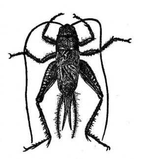

**Figure 7.4:** *Gryllus* sp., cricket

If a generic term existed in POc, either for grasshoppers, or for grasshoppers + crickets + cicadas (+ mantises), I have not been able to reconstruct it. Although I have a number of reconstructions, their reflexes show considerable variation in gloss. Some terms refer to ‘singing insect’, which may indicate either cricket or cicada. Lack of agreement in glosses may reflect indifference among speakers, although I would expect a generic term if particular varieties were not seen as important. Some languages have simply adopted verb forms for ‘grasshopper’ - etymons from Kove (*piti-piti* ‘jumping insect found in beach rubbish’) and Raga (*visi[ribi]* ‘taro plant hopper’) are from POc *pitik ‘spring up suddenly’/ POc *pitik-pitik jump repeatedly. In Dobu crickets are named *kelei ʔana toeʔita*, literally ‘wallaby’s teacher’ (Ralph Lawton. pers. comm.). A grasshopper named *kokoru-bote* in Arosi is remarkable for the use found for it. It is described as ‘a large grasshopper, put on one’s head to eat lice’ (from *koru* ‘eat’, *bote* ‘lice’). Together with mantises and stick insects, grasshoppers and crickets are valued as food. Kwaio has a term, *faʔafulu* glossed as ‘generic term for edible insects, incl. grasshoppers, stick insects etc.’ Their appeal would no doubt be as a kind of snack food, a chance variation on their regular diet.

| **POc** |  | *sisi(r,R) | ‘orthopterous insect’ |
| --- | --- | --- | --- |
| NNG | Poeng | *sisi* | ‘grasshopper’ |
| NNG | Lukep (Pono) | *sis* | ‘grasshopper’ |
| NNG | Kaulong | *u-sis* | ‘grasshopper’ |
| NNG | Sengseng | *e-sis* | ‘grasshopper’ |
| NNG | Gedaged | *sis* | ‘grasshopper, locust’ |
| PT | Iduna | *sili(fa)* | ‘k.o. small grasshopper’ |
| MM | Tangga | *sisi* | ‘cicada’ |
| MM | Nehan | *sir-siri(alum)* | ‘cricket’ |
| MM | Nduke | *hiri-ri* | ‘k.o. cicada’ |
| MM | Roviana | *sisiri* | ‘k.o. cicada (Diceropyga obtecta)’ |
| SES | Kwara’ae | *sīsī* | ‘generic for beetles and insects’ |
| SES | To’aba’ita | *sīsī* | ‘generic for beetles and fireflies’ |
| NCV | Nese | *sis* | ‘chirp, of cicada’ |

cf. also:

| MM | Tolai | *titi(tiŋ)* | ‘k.o. small locust’ |
| --- | --- | --- | --- |
| NCV | Mwotlap | *titi(key)* | ‘grasshopper’ |

Any resemblance between POc *riŋa and PROc *liŋo-liŋo is probably fortuituous.

| **POc** |  | *riŋa | ‘orthopterous insect’ |
| --- | --- | --- | --- |
| Adm | Drehet | *riŋ* | ‘cricket’ |
| PT | Molima | *lia* | ‘cicada’ |
| MM | Nehan | *(kaka)riŋ* | ‘grasshopper’ |

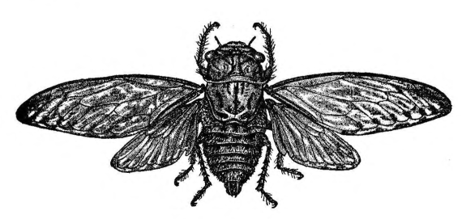

**Figure 7.5:** Cicada

| **PROc** |  | *liŋo-liŋo | ‘night insect, probably a cricket’ |
| --- | --- | --- | --- |
| Mic | Kiribatese | *niŋo-niŋo* | ‘an insect which chirps at night’ |
| Fij | Bauan | *liŋo-liŋo* | ‘night insect, esp. k.o. moth’ |
| Pn | Tongan | *liŋo-liŋo* | ‘k.o. cricket’ |
| Pn | Samoan | *liŋo-liŋo* | ‘cicada, sings in daytime. *ʔālisi* sings at night’ (Stair 1983: 207) |
| Pn | Tikopia | *riŋo-riŋo* | ‘cricket (Gryllidae). Rarely seen’ |

| **POc** |  | *siko | ‘grasshopper’ |
| --- | --- | --- | --- |
| MM | Tabar | *ciko* | ‘grasshopper’ |
| SES | Lau | *siko* | ‘grasshopper’ |
| SES | Kwara’ae | *siko* | ‘grasshopper’ (Whitmore 1966) |
| SES | To’aba’ita | *siko* | ‘generic for a class of insects that includes locusts, grasshoppers, stick insects, mantises, cicadas’ |
| NCV | Nese | *(narra)sɣo* | ‘grasshopper’ (*narra* ‘?’) |

| **POc** |  | *sakʷa | ‘grasshopper or stick insect’ |
| --- | --- | --- | --- |
| NNG | Gedaged | *sok(sok)* | ‘stick insect’ |
| NNG | Takia | *sok* | ‘large insect, prickly, with six legs, eaten’ |
| PT | Molima | *saga-saga* | ‘green mantis (eaten)’ |
| MM | Kara (East) | *saɣwa* | ‘grasshopper’ (reflects *saqa) |
| Mic | Carolinian | *tāxa* | ‘grasshopper’ |

The next term, POc *lale ‘cicada’, is based on external evidence plus reflexes from two closely related languages. It remains an uncertain reconstruction.

| **PAn** |  | *lalay | ‘cicada’ (Blust 2002) |
| --- | --- | --- | --- |
| **POc** |  | *l(a,e)le | ‘cicada’ |
| PT | Molima | *lele* | ‘a mountain insect with very attractive cry’ |
| PT | Dobu | *lele* | ‘cicada’ |

The next reconstruction is reliable in form only at PEOc level, and there is little consistency of gloss even within Polynesian languages.

| **PEOc** |  | *(s,j)eqe | ‘grasshopper ?’ |
| --- | --- | --- | --- |
| SES | Bugotu | *se-se* | ‘grasshopper’ |
| Fij | Rotuman | *jei* | ‘cricket’ |
| **PPn** |  | *seqe | ‘insect spp. including mantis, stick insect, locust’ |
| Pn | Tongan | *heʔe* | ‘locust, grasshopper’ |
| Pn | Niuean | *hē* | ‘grasshopper, locust’ |
| Pn | Rennellese | *seʔe* | ‘k.o. small cricket’ |
| Pn | Samoan | *sē* | ‘stick insect’ |
| Pn | Tikopia | *sē* | ‘stick insect; mantis’ |
| Pn | Tokelauan | *hē* | ‘locust, grasshopper’ |

John Lynch (pers. comm.) notes a number of NCV forms for ‘cicada’ (Mota *puŋa*, Naman *bəgale*, Neve’ei *na/bugali* Tape *bəŋale*, Paamese *ha/vuŋalii*). and Namakir *biŋaleh* ‘cricket’ which support PNCV *bu(g,ŋ)alis(V). This in turn suggests a possible relationship with the following PPn reconstruction, *kālisi.

| **PPn** |  | *kālisi | ‘cicada, cricket’ |
| --- | --- | --- | --- |
| Pn | Tongan | *kālihi* | ‘k.o. cricket’ |
| Pn | Samoan | *ʔālisi* | ‘cicada, cricket (night insects)’ |
| Pn | Ifira-Mele | *karisi* | ‘cicada’ |

| **PPn** |  | *wāwā | ‘orthopterous insect’ |
| --- | --- | --- | --- |
| Pn | Niuean | *vā* | ‘insect sp.’ |
| Pn | Rarotongan | *vāvā* | ‘cricket’ |
| Pn | Tongareva | *vāvā* | ‘grasshopper, cricket’ |
| Pn | Mangareva | *vāvā* | ‘insect sp.’ |
| Pn | Tahitian | *vāvā* | ‘praying mantis, stick insect’ |
| Pn | Tuamotuan | *vāvā* | ‘grasshopper, stick insect’ |

## 13. Mantises (Order Mantodea = ‘like a prophet’), stick insects (Order Phasmatodea = ‘like a ghost’)

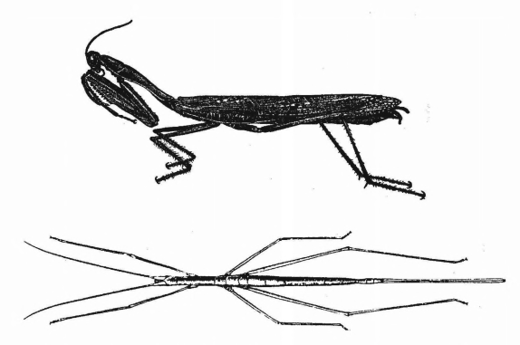

**Figure 7.6:** **Above** Praying mantis. **Below** Stick insect.

Although there is some confusion of gloss within cognate sets, it seems clear that POc speakers distinguished praying mantises (*papa) from stick insects (*mimis-mata). The ability to project a milky chemical painful to the skin which is reflected in POc *mimis-mata is a defensive mechanism of at least some stick insects (Serkan Alasya, CSIRO Entomology, pers. comm.).

| **PMP** |  | *(kali)papa | ‘praying mantis, grasshopper’[^7] |
| --- | --- | --- | --- |
| **POc** |  | *papa | ‘praying mantis’ |
| MM | Tolai | *pap* | ‘praying mantis’ |
| MM | Roviana | *papa(maho)* | ‘praying mantis’ (also *ma*/*maho* ‘green mantis’) |
| MM | Nehan | *popo(hɔsoi)* | ‘walking stick insect’ |

POc *mimis-mata, literally ‘urinate’ + ‘eye’, reflects awareness that the stick insect can eject a fluid which causes pain if it touches the eye. One of the better-known Phasmatodea of the Oceanic region is Megacrania batesii, the pandanus stick insect.

| **POc** |  | *mimis-mata | ‘stick insect’ |
| --- | --- | --- | --- |
| MM | Roviana | *mimi-mata* | ‘walking-stick insect which ejects a fluid said to cause intense pain should it touch the eye’ |
| NCV | Raga | *me-merehi-mata* | ‘praying mantis’ (lit. ‘urinate on eye’) |
| Fij | Wayan | *mīmī-mata* | (1) ‘praying mantis’; (2) ‘stick insect (generic)’ (lit. ‘urinate in eye’) |

cf. also:

| PT | Molima | *mata-seʔa-seʔa* | ‘large poisonous beetle’ (*seʔai* or *seiʔa* ’to squirt poison, as a millipede; lit. squirt in eye??) |
| --- | --- | --- | --- |

Closely related to stick insects are leaf insects. The only terms I have located are descriptive compounds: Tawala (PT) *hiaga luguna* (*hiaga* ‘?’, *lugu* ‘leaf’), Tongan *moko-moko tuʔaniu* (*moko-moko* ‘crawling insect, *tuʔaniu* ‘midrib of coconut leaflet’), and Rennellese *manu gaukei* (‘insect’ + ‘leaf’).

Some varieties of mantis and stick insect are listed as edible in a number of languages.

## 14. Fireflies (Order Coleoptera = ‘sheath wings’: Family Lampyridae)

Judging from ethnographic references and brief elaborations in wordlists, it is fireflies, among all the insects of the Oceanic world, which are most associated with supernatural qualities. For Takia (NNG) speakers, a firefly, *lutot*, is thought to be a messenger of someone’s death (Bugenhagen wordlist). The term for a firefly in Sissano (NNG), *mas eyiaw*, is a compound term, *mas* being defined as ‘devil; spirit of dead relative’ and *eyiaw* as ‘evil spirit; thief’ (Whitacre wordlist). Seligmann quotes a report from Bartie Bay (Wedau, PT) that ‘if a firefly enters a house at night, it is a sign that someone in the house will die.’ (1910:653). Molima (PT) speakers regard fireflies as emissaries of witches who enter the house at night in order to report back on who is there, and for that reason they are killed as soon as they are seen (Ann Chowning, pers. comm.). In Nakanai (MM), although its speakers consider that fireflies embody spirits of the dead, they are delighted if a firefly enters the house at night, because it is a sign that someone recently dead is paying a visit (Ann Chowning, pers. comm.). Ivens writes that fireflies are popularly classified as ghosts in Sa’a and Ulawa (1927:189), and in his Sa’a dictionary he defines fireflies (*pulu-pulu*) as ‘souls of dead persons’. The Tolo people of Guadalcanal regard cicadas and fireflies as the ghosts of unknown people, or ghosts of the forest (Ivens 1930:229). Tamambo (NCV) speakers are frightened of them, and try to avoid them as ‘little devils’ (Dorothy Jauncey pers. comm.). In Wayan Fijian, fireflies (*tōtōvuata*) are believed to be a sign of the gods inspecting fruit crops. The Rennellese see a firefly as the embodiment of a goddess.

The belief that fireflies are messengers of doom is an ancient one among Austronesian speakers. Blust (pers. comm.) provides additional evidence from Isneg (northern Philippines) that fireflies are precursors of death, and Karo Batak (northern Sumatra) where their presence in a house signals that thieves will come. Of all POc reconstructions, then, I should expect that for ‘firefly’ to be most likely to retain the *kali-*/*qali-* indicator of supernatural status. I have limited evidence supporting two reconstructions derived from PMP *qali-petpet, POc *qali-popot ‘firefly’ and POc *(k,q)ali-totop ‘firefly’, the latter with metathesis. POc *(k,q)ali-totop depends on one reflex, from Rennellese, for reconstruction of its first element and on another, Nduke, for reconstruction of its second element.

| **PMP** |  | *qali-petpet | ‘firefly’ (ACD: WMP) |
| --- | --- | --- | --- |
| **POc** |  | *qali-popot | ‘firefly’ |
| NCV | Lewo | *le-popo* | ‘firefly’ |
| NCV | Tamambo | *vovo(mbo)* | ‘firefly; regarded as little devils and avoided’ |

| **PMP** |  | *qali-petpet | ‘firefly’ (ACD) |
| --- | --- | --- | --- |
| **POc** |  | *(k,q)ali-totop | ‘firefly’ (metathesis) |
| NNG | Takia | *lu-tot* | ‘firefly’ |
| MM | Tangga | *kel-tot* | ‘firefly’ |
| MM | Nduke | *alal-totovo* | ‘luminous flying insect, its light flashes on-off’ |
| Pn | Rennellese | *ʔagi-to* | ‘firefly, seen inland, a rare phenomenon; believed to be the embodiment of the goddess Sikingimoemoe, and might not be killed’ |

A putative reconstruction, POc *bulu-bulu ‘firefly’, must be regarded as dubious because witnesses are from adjoining subgroups where borrowing cannot be ruled out. Etymons may be derived from POc *bulut ‘gum’ whose reflexes can include ‘a torch (of gum)’, and thus extend to ‘light, firefly’.

| MM | Nehan | *bol-bol* | ‘lightning bug, near swamps’ |
| --- | --- | --- | --- |
| SES | Gela | *bulu (tora)* | ‘firefly; phosphorescent fungus’ (bulu ‘torch, lamp’)[^8] |
| SES | Sa’a | *pulu-pulu* | ‘firefly. Regarded as souls of dead persons, and killed when they enter a house’ |
| SES | Kwaio | *bulu-bulu* | ‘star; firefly. Believed (esp. when enters house) to be a messenger from an ancestral spirit.’ |
| SES | Arosi | *buru-buru* | ‘firefly; torch (of gum)’ |
| SES | Arosi | *buburu(atoā)* | ‘k.o. cricket’ (atod ‘noon’) |
| SES | ’Are’are | *puru-puru* | ‘star; firefly’ |
| SES | To’aba’ita | *būbulu* | ‘star; firefly; beetle sp.’ |

Other terms use reflexes of POc *mata ‘eye’, sometimes extended to ‘star’ and ‘firefly’.

| NNG | Poeng | *mata* | ‘eye; star; firefly’ (*mata-balaŋ* ‘bee/wasp’) |
| --- | --- | --- | --- |
| MM | Nakanai | *mata(tabu)* | ‘star; firefly’ |
| MM | Nakanai | *mata(laso)* | ‘k.o. long glow worm’ |

Other languages may make similar associations between fireflies, stars and sometimes phosphorescence.

| NNG | Sengseng | *limlek* | ‘firefly; star’ |
| --- | --- | --- | --- |
| MM | Roviana | *pinoro* | ‘phosphorescence as seen in the sea or on fireflies etc.’ (*pino-pino* ‘a star’) |

## 15. Beetles (Order Coleoptera)

Although there are thousands of different beetle species, very few taxa are named in wordlists. Only two POc reconstructions have been made, and in the first listed below there are grounds for believing that the gloss given in many of the daughter languages is a recent adaptation. The large rhinoceros beetle (Oryctes rhinoceros), which bores into the crown of the coconut palm and is considered a serious pest in many parts of the Pacific, is believed to have been introduced from southeast Asia only in the 20th century (Gressitt & Homabrook 1985:34). A beetle similar in appearance and behaviour is Xylotrupes gideon, found in almost all parts of New Guinea. Presumably, speakers used an existing beetle term to refer to the introduced beetle. The second reconstruction, POc *kamak, probably refers to longicorn beetles, those with extremely long antenna (Family Cerambycidae), the larvae of which attack timber.

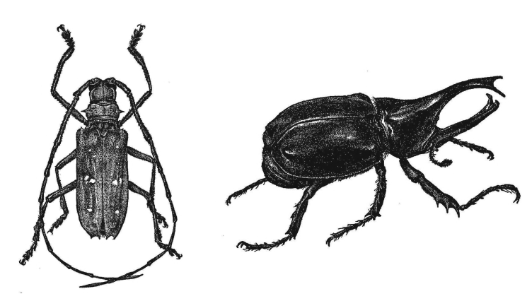

**Figure 7.7:** **Left** Longicom beetle. **Right** Oryctes rhinoceros, rhinoceros-beetle.

| **POc** |  | *tabuRuRu | ‘k.o. beetle’ |
| --- | --- | --- | --- |
| NNG | Sengseng | *taput* | ‘an enormous black beetle’ |
| MM | Nakanai | *tabuburu* | ‘coconut beetle’ (expect †*tabururu*) |
| MM | Tabar | *taburu(ŋa)* | ‘beetle’ |
| MM | Tolai | *taburur* | ‘horned beetle’ |
| MM | Kara (East) | *tevu(ŋun)* | ‘rhinoceros beetle’ |
| SES | Gela | *tabelulu* | ‘rhinoceros beetle’ |
| SES | Bugotu | *tabilolo* | ‘rhinoceros beetle’ |
| NCV | Uripiv | *barur* | ‘yam weevil, Papuana beetle’ (loss of first syllable unexplained) |
| SV | Sye | *n-tompi* | ‘k.o. beetle’ |

cf. also:

| NNG | Mapos Buang | *abu* | ‘rhinoceros beetle’ |
| --- | --- | --- | --- |
| MM | Nduke | *vure* | ‘rhinoceros beetle’ |

| **POc** |  | *kamak | ‘beetle, possibly longicom’ |
| --- | --- | --- | --- |
| NNG | Kaulong | *kamak* | ‘k.o. insect; large, edible, found inside the hollows of trees’ |
| NNG | Yabem | *kaŋ* | ‘beetle: capricorn beetle, stag beetle, homed beetle, weevil’ |
| NNG | Sengseng | *makah* | ‘longicorn beetle’ (metathesis) |
| PT | Iduna | *kama* | ‘large insect with long fat body’ |
| Pn | Tikopia | *kama* | ‘insect, possibly of various types, attacks cultivated plants’ |

cf. also:

| MM | Nakanai | *komaga* | ‘long thin black beetle, edible, longicorn beetle’ |
| --- | --- | --- | --- |

A surprising omission from most wordlists are terms for the taro beetle (Papnana uninodis). Although these beetles may be as long-established in the region as the tubers which we know were cultivated in Proto Oceanic times, I have not been able to reconstruct a term for them other than PSES *ko[l,R]o-ko[l,R]o ‘beetle that attacks plants’. Damage to the tuber is caused by the adult beetles, and not by their larval stage which feeds on soil and roots (Robin Hide, pers. comm.). I can locate very few terms for the pest in Western Oceanic languages, none cognate. Although damaged tubers cause significant economic loss in today’s marketing terms, it may be that the damage was of little significance when tubers were primarily for home consumption.

| **PSES** |  | *ko[l,R]o-ko[l,R]o | ‘beetle that attacks plants’ |
| --- | --- | --- | --- |
| SES | Bugotu | *kololo* | ‘coconut beetle’ |
| SES | Gela | *kololo* | ‘taro-eating beetle’ |
| SES | ’Are’are | *ʔoro-ʔoro* | ‘taro-boring beetle’ |
| SES | To’aba’ita | *ʔoro(kʷao)* | ‘k.o. white worm, attacks sugar-cane stems’ (*kʷao* ‘white’) |

cf. also:

| SES | Sa’a | *ʔoroʔoro* | ‘beetle that bores into yams’ (for †*ʔoloʔolo*) |
| --- | --- | --- | --- |

Wordlists contain a few references to edible beetles. Sudest (PT) has a term *gilai* ‘a large black sago beetle; people eat both the adults and the larvae’; Nakanai (MM) has *komaga* ‘an edible insect like a long thin black beetle’ and *bureka* ‘large (6 ins) edible insect found in trees’; Wayan (Fij) has *gou* ‘large beetle, *Coleopterus* sp., 2 inches long with hard shell. Eaten by some people’.

## 16. Cockroaches (Order Blattodea = ‘light avoiders’)

Three POc reconstructions and one lower-level reconstruction can be made for ‘cockroach’.

| **PAn** |  | *Sipes | ‘cockroach’ (ACD) |
| --- | --- | --- | --- |
| **POc** |  | *ipos | ‘cockroach’ (ACD) |
| Adm | Nali | *yih* | ‘cockroach’ |
| Adm | Nauna | *ih* | ‘cockroach’ |
| Adm | Drehet | *ih* | ‘cockroach’ |
| NNG | Mutu | *up* | ‘cockroach’ |
| NNG | Kaulong | *e-yus* | ‘cockroach’ |
| NNG | Sengseng | *e-yus* | ‘cockroach’ |
| MM | Tolai | *ipi(na)* | ‘sp. beetle’ (*ipina-koto* ‘cockroach’) |
| NCal | Cèmuhî | *iwet* | ‘cockroach’ |
| NCal | Nemi | *yuet* | ‘cockroach’ |

cf. also:

| NCV | Raga | *ihi* | ‘cockroach’ (for expected *ivi*) |
| --- | --- | --- | --- |

| **POc** |  | *musi | ‘cockroach’ |
| --- | --- | --- | --- |
| PT | Roro | *muhi* | ‘cockroach’ (for expected *musi*) |
| MM | Maringe | *mhi-mhi(gi)* | ‘stink beetle’ |
| SES | Bugotu | *muhu* | ‘cockroach, beetle’ |
| SES | Gela | *muhu* | ‘cockroach’ |
| SES | Tolo | *musu* | ‘cockroach’ |
| SES | Ghari | *mosu* | ‘small cockroach’ |

Final *-u* for †*-i* in the SES items appears to reflect vowel assimilation.

The next set shows a variety of reduplication patterns. Some Polynesian terms show possible contamination from English cockroach or Spanish cucaracha.

| **POc** |  | *kʷaru-kʷaru | ‘cockroach’ |
| --- | --- | --- | --- |
| PT | Bwaidoga | *kʷalu-kʷalu* | ‘cockroach’ |
| MM | Nehan | *kur-kuru* | ‘cockroach’ |
| MM | Banoni | *karo* | ‘small white cockroach’ |
| Pn | Tongan | *kakalu* | ‘large cricket/cicada sp.’ |
| Pn | East Futunan | *kakalu* | ‘that which smells bad’ |
| Pn | Samoan | *alalū* | ‘cockroach’ |
| Pn | Tahitian | *aʔararū* | ‘small beetle’ |
| Pn | Māori | *kekererū* | ‘stinkroach’ |
| Pn | Hawaiian | *ʔelelū* | ‘cockroaches’ |

| **PPn** |  | *moŋa-moŋa | ‘cockroach’ (pollex) |
| --- | --- | --- | --- |
| Pn | Tongan | *moŋo-moŋa* | ‘any kind of beetle or cockroach’ |
| Pn | Niuean | *moŋa-moŋa* | ‘cockroach’ |
| Pn | Samoan | *moŋa-moŋa* | ‘cockroach’ |
| Pn | Nanumean | *moŋa-moŋa* | ‘beetle sp.’ |
| Pn | Tokelauan | *moŋa-moŋa* | ‘cockroach’ |

## 17. Grubs, caterpillars

Grubs and caterpillars are the larval stages of beetles (Coleoptera) and butterflies (Lepidoptera). Particular kinds are more likely to be named if they are a useful food source, or if they attack crops.

One which is widely recognised is the edible sago grub (Order Coleoptera, family Curculionidae), a valuable source of protein. Sago grows in low-lying, swampy areas of Melanesia where other food plants do not thrive. Lack of the means of a varied diet may contribute to the specialised sago grub cultivation employed by the Labu (NNG) people.[^9] In Sissano the sago grubs, *yiat*, are used in food offerings to the spirits in some healing ceremonies (Whiteacre wordlist).

| **PMP** |  | *qabated | ‘sago grub’ (Blust 2002) |
| --- | --- | --- | --- |
| **POc** |  | *qapator | ‘sago grub, edible’ |
| Adm | Loniu | *het* | ‘sago grub’ |
| Adm | Ere | *ehet* | ‘sago grub’ |
| Adm | Titan | *aet* | ‘sago grub’ (for †*ahat*) |
| Adm | Pak | *keher* | ‘sago grub’ |
| Adm | Penchal | *kahɛt* | ‘sago grub’ |
| Adm | Lenkau | *kehetr* | ‘sago grub’ |
| NNG | Sissano-Arop | *yiat* | ‘sago grub’ |
| NNG | Kove | *awatolu* | ‘sago grub’ |
| NNG | Gedaged | *gafat* | ‘big grub found in rotten sago logs. Eaten raw or roasted. A great delicacy’ (initial *g-* unexpected) |
| PT | Lala | *avako* | ‘grub, found in sago palms’ |
| SES | Gela | *vato* | ‘k.o. grub, eaten as food on Mala’ |
| SES | Ghari | *vato* | ‘white worm in decayed tree’ |
| SES | Arosi | *hao* | ‘white grub in rotten wood, eaten’ (first syllable lost) |
| SES | Lau | *safao* | ‘grub that eats sago palms’ |
| SES | Kwaio | *lafao* | ‘large edible grub, larva of stag beetle’ |
| SES | Sa’a | *sahao* | ‘the grub found in fallen logs of breadfruit tree, supposed to turn into the cockchafer beetle’ |
| SES | ’Are’are | *rahao* | ‘big, white worm, lives in dead trees’ |
| NCV | Mota | *vato* | ‘white grub found in dead trees, eaten’ |
| NCV | Lewo | *varo* | ‘grub found in dead wood, edible’ |
| NCV | Raga | *avato* | ‘large white insect found in trees, edible, larva of longhorn beetle’ |
| SV | Sye | *n-avat* | ‘edible wood grub’ |
| SV | Anejom̃ | *n-ahat* | ‘edible wood grub’ |
| Fij | Wayan | *avato* | ‘wood-boring grubs of various species’ |
| Fij | Bauan | *yavato* | ‘grub in a tree, develops into the coleopterous called *qou*’ |
| Pn | Tongan | *ʔofato* | ‘k.o. white grub found in timber, sometimes eaten’ |
| Pn | Samoan | *ʔafato* | ‘large edible grub, found in dry trees’ (*ʔ-* unexpected) |
| Pn | East Futunan | *ʔafato* | ‘larvae which are eaten; large edible grub, found in dry trees’ |
| Pn | Rennellese | *ahato* | ‘larva of longicorn beetle Olethrus tyrranus’ (for †*ʔahato*) |

cf. also:

| PT | Sinaugoro | *kavata* | ‘caterpillar’ |
| --- | --- | --- | --- |
| MM | Nakanai | *(k,g)avato* | ‘black lizard, found in rotten trees’ (*kopa* ‘larva of a beetle, found in trees and eaten’) |

POc *muno may have been a generic term for caterpillars. Reflexes are not found in Central Pacific where a reflex of POc *qanupe is the most widespread term for ‘caterpillar’.

| **POc** |  | *muno[-muno] | ‘caterpillar, grub’ |
| --- | --- | --- | --- |
| Adm | Lou | *mon-muon* | ‘caterpillar’ |
| MM | Simbo | *mu-muno* | ‘worm’ |
| MM | Nduke | *mu-muno* | ‘looper caterpillar’ |
| MM | Roviana | *muno-muno* | ‘general name for caterpillars and grubs’ |
| SES | Bugotu | *muno* | ‘caterpillar’ |
| SES | Lau | *muno* | ‘caterpillar’ |
| SES | Sa’a | *muno* | ‘larva, chrysalis’ |
| SES | ’Are’are | *muno* | ‘caterpillar’ |
| SES | To’aba’ita | *muna* | ‘k.o. caterpillar that turns into a butterfly’ |
| Mic | Puluwatese | *mūn* | ‘caterpillar’ |
| Mic | Carolinian | *mʷūl* | ‘generic term for maggots, larvae or small worms’ |
| Mic | Woleaian | *mʷura* | ‘caterpillar, silkworm’ |

cf. also:

| MM | Nduke | *meno* | ‘taro beetle’ |
| --- | --- | --- | --- |

WOc cognates of POc *qanupe refer to trepangs,[^10] also known as bêche-de-mer or sea slugs (ch.4, §5.2.1), while Eastern Oceanic cognates refer to caterpillars. Without external cognates, the meaning of POc *qanupe is indeterminate.

| **POc** |  | *qanupe | ‘caterpillar or k.o. sea cucumber (indeterminate)’ |
| --- | --- | --- | --- |
| **PWOc** |  | *qanupe | ‘sea cucumber, holothurian’ |
| NNG | Kove | *anuwe* | ‘trepang’ |
| PT | Dobu | *kanue* | ‘bêche de mer’ |
| PT | Galea | *anue* | ‘general term for all sea cucumbers’ (Lawrence Rutter pers.comm.) |
| MM | Nakanai | *haluve* | ‘trepang’ |
| **PEOc** |  | *qanupe | ‘caterpillar’ |
| SES | Ghari | *nive* | ‘caterpillar’ |
| Fij | Rotuman | *aniha* | ‘caterpillar, maggot’ |
| Fij | Bauan | *(b)anuve* | ‘caterpillar’ |
| Pn | Tongan | *ʔunufe* | ‘caterpillar (generic)’ |
| Pn | Samoan | *ʔanufe* | ‘worm, caterpillar’ |
| Pn | Tikopia | *unūfe* | ‘caterpillar’ |
| Pn | Nanumean | *anufe* | ‘caterpillar, worm, slug, etc.’ |
| Pn | Tuamotuan | *anuhe* | ‘caterpillar’ |

## 18. Centipedes (Class Chilopoda): Millipedes (Class Diplopoda)

Another *qali- term, POc *qalipan ‘centipede’, is reconstructable, probably embracing millipedes as well. Evidence of an association between centipedes and the supernatural comes from ethnographic descriptions as well as linguistic clues. For instance, Sengseng (NNG) speakers consider centipedes to be supernatural beings, and carefully remove them from their houses (Ann Chowning, pers. comm.). Elbert’s Rennellese dictionary defines *ʔagi-paipai* as ‘centipede, considered the embodiment of non-worshipped deities and a loathsome creature’. In his Tikopia dictionary Firth defines *morokau* as ‘centipede. Trad. held to be frequent embodiment of spirit’. There is also a Samoan term *atua-loa* ‘k.o. centipede with poisonous bite’, whose prefix *atua-* has supernatural significance (discussed in §27). In addition to the *qalipan cognate set I list non-cognate terms for centipede from a range of languages across several subgroups which all exhibit a reflex of the *qali-*/*kali-* prefix.

Reflexes of *qalipan are numerous and widespread. As well, I have a number of lower-level reconstructions, possibly for particular kinds of centipede. Two kinds of centipede/millipede are described in wordlists, categorised by behaviour or luminosity rather than number of legs. One, when threatened, squirts a kind of acid from between its scales which can cause blisters or even permanent eye damage, while a second is described as phosphorescent or luminous. A millipede in Arosi (SES), *doŋa*, is also singled out as having a vile smell. I have one lower-level reconstruction for the luminous variety, PPn *taqe-tuli ‘phosphorescent centipede or millipede’, whose first element is derived from POc *taqe ‘excrement’, implying strongly that the creature is considered unpleasant in Central Pacific languages. In Tahiti, however, where there are two kinds, not venomous, one short and thick and light brown, the other long, threadlike and phosphorescent, they were well regarded. Teuira Henry (1971:391) writes that ‘when a centipede fell upon a wound or bruise of any kind, it soon healed. If it crawled upon a sick person, a speedy recovery followed.’

| **PAn** |  | *qalu-Sipan | ‘centipede’ (ACD) |
| --- | --- | --- | --- |
| **PMP** |  | *qalu-hipan | ‘centipede’ (ACD) |
| **POc** |  | *qalipan | ‘centipede’ |
| Adm | Mussau | *aliena* |  |
| Adm | Wuvulu | *ali-alifa* |  |
| NNG | Manam | *alia* |  |
| NNG | Mangga | *garivaŋ* |  |
| NNG | Yalu | *kanif* |  |
| NNG | Wampur | *ganef* |  |
| PT | Maopa | *ɣaiva* |  |
| PT | Gumawana | *ganiva* |  |
| PT | Sariba | *kalihai* |  |
| PT | Duau | *ganihana* |  |
| PT | Motu | *aiha* |  |
| MM | Bola | *ɣaliua* |  |
| MM | Halia | *lihaŋ(a)* |  |
| MM | Nehan | *hilaŋ* | (metathesis) |
| MM | Nduke | *livaŋ(a)* |  |
| SES | Gela | *liva* |  |
| SES | Bugotu | *liva* |  |
| SES | Lengo | *aliva* |  |
| SES | Lau | *safila* | (metathesis) |
| SES | Kwaio | *lalifa* |  |
| SES | Arosi | *(karikari)ʔariha* |  |
| Fij | Rotuman | *aniha* | ‘maggot; also applied to many kinds of caterpillars and millipedes’ |
| Fij | Bauan | *yaliva* | ‘a red millipede, possibly generic for millipedes’ |

cf. also:

| Pn | Rennellese | *ʔagipaipai* |  |
| --- | --- | --- | --- |

Other terms for centipede which apparently exhibit a reflex of the *qali-*/*kali-* prefix include:

| Adm | Drehet | *kxane-pup* | ‘centipede’ |
| --- | --- | --- | --- |
| PT | Molima | *gani-geva* | ‘centipede’ |
| MM | Ririo | *kali-gava* | ‘centipede’ |
| MM | Sisiqa | *kala-gava* | ‘centipede’ |
| MM | Babatana | *kali-gava* | ‘centipede’ |

The compound terms below yield a reconstructed first element, PWOc *mʷali-.

| **PWOc** |  | *mʷali- | ‘millipede’ |
| --- | --- | --- | --- |
| PT | Bwaidoga | *mʷali(keke)* | ‘millipede (yellow, causing irritation or burn to skin when it squirts acid from between scales)’ |
| PT | Kilivila | *mʷani(ta)* | ‘centipede’ |
| MM | Maringe | *mali(so)* | ‘millipede’ |

cf. also:

| PT | Molima | *pʷali(keke)* | ‘millipede’ |
| --- | --- | --- | --- |

POc *weli (1) ‘fireworm, sea centipede’; (2) ? ‘k.o. millipede’ is included in chapter 4, §7.2.

| **PPn** |  | *taqe-tuli | ‘phosphorescent centipede/millipede’ (pollex) |
| --- | --- | --- | --- |
| Pn | Tongan | *teʔe-tuli* | ‘phosphorescent centipede’ |
| Pn | Rennellese | *taʔ-tugi* | ‘long and slender centipede variety’ |
| Pn | Samoan | *tae-tuli* | ‘phosphorescent millipede’ |
| Pn | Tikopia | *tae-turi* | ‘millipede’ |

cf. also:

| Fij | Rotuman | *turi* | ‘phosphorescent centipede’ (Pn borrowing) |
| --- | --- | --- | --- |

In Bugotu (SES) the term for a phosphorescent centipede, *liva tora*, is a literal description: (*liva* ‘centipede’, *tora* ‘phosphorescent’).

## 19. Scorpions (Class Arachnida: Order Scorpiones)

A substantial number of terms for scorpions have been collected, but only a single reconstruction, Proto SE Solomonic *vari ‘scorpion’ (not listed here) has been possible. In the Solomons, many terms are compounds or phrases which include the word for centipede (Gela *liva-ni mala*, Birao *kaukau-liva*, Lengo *aliva-ni-ɣoro*). Although centipedes and scorpions belong to different zoological classes, the linking of the two creatures in this way may be due to the similar appearance of grasping pincers, and to the facts that both are capable of delivering a severe bite or sting, and both frequent the same habitat, under rocks or leaf litter. The scorpion is named as crab-like in Gapapaiwa (*gʷaɣa-gʷaɣa* ‘scorpion; idiom for one who moves slowly and fearfully on heights) (*gʷaɣa* ‘crab (generic)’) and possibly also in Molima (*dowa* ‘scorpion, land crab’), although Chowning adds a question mark to her gloss.

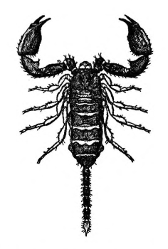

**Figure 7.8:** *Honnurus* sp., scorpion

## 20. Spiders (Order Araneae)

Although POc speakers would undoubtedly have named a range of spiders, I have not been able to link reconstructions with specific kinds of spider. I have only one lower-level example in which a name is assigned to a particular spider — PCP *tuku-tuku ‘k.o. spider that lets itself down by a single thread’. POc *lawaq, traceable back to PAn, with cognates right across the Oceanic region, may have referred primarily to ‘spider’ but by POc times had come to refer as well to ‘spider web’ and ‘k.o. fish net’ (see vol.1,212). I also find a number of reconstructions with formal similarities, including POc *koko, POc *gagao~*(g,k)a(g,k)a-, PWOc *kuku, and PEOc _*[ko]ko-miji. Some kind of word play has evidently taken place, although I have no ethnographic evidence that particular spiders are associated with any kind of supernatural belief or taboo. On the contrary, they are freely eaten in many communities. Wordlists of a number of languages including Molima and Sinaugoro (PT), Takia (NNG) and Hawaiian (Pn), record particular kinds of edible spider.

Reconstructions other than *lawaq have an unusually large number of reflexes which are compounds with a non-reflected element. These reconstructions may refer to particular kinds of spider. As Pawley (2000: 8) has noted, names for folk specifics in plants and animals, or, to be more exact, the secondary or modifying terms in binomials, are notoriously unstable and will, in most cases, not be reconstructable for a language as remote in time as POc.

| **PAn** |  | *lawaq | ‘spider’ (Blust 2002) |
| --- | --- | --- | --- |
| **POc** |  | *lawaq | ‘spider, spider web’ (Also ‘fish net’) |
| Adm | Loniu | *(wi)law* | ‘spider’ |
| NNG | Tuam | *lawag* | ‘spider’ |
| NNG | Gitua | *lawak* | ‘spider’ |
| NNG | Malai | *lawak* | ‘web’ |
| NNG | Wogeo | *lawa* | ‘spider’ |
| PT | Bwaidoga | *nawaya* | ‘spider’ |
| PT | Gapapaiwa | *nawa-nawa* | ‘spider web’ |
| PT | Sudest | *lawa* | ‘spider’ |
| PT | Motu | *vala-vala* | ‘cobweb’ (metathesis) |
| MM | Vitu | *lava* | ‘spider’s web’ |
| SES | Lau | *lakʷa* | ‘k.o. large yellow spider and large web’ |
| SES | Kwaio | *lakʷa-lakʷa* | ‘spider web’ |
| SES | ’Are’are | *rawa* | ‘spider, cobweb’ |
| SES | Sa’a | *lawa* | ‘spider’s web, spider’ |
| SES | Arosi | *rawa* | ‘spider, cobweb, small net’ |
| NCV | Mota | *(ta)lau* | ‘cobweb, either single line or web’ |
| NCV | Nguna | *(ka)lau* | ‘spider (web)’ |
| SV | Anejom̃ | *ni-lva* | ‘spider web’ |
| Fij | Bauan | *lawa* | ‘fishing net’ |
| Fij | Bauan | *viritā lawa-lawa* | ‘cobweb’ |
| Fij | Bauan | *tina-ni-viritā lawa-lawa* | ‘spider’ (lit. ‘mother of cobweb’) |

PPn *lewe is probably cognate, with reduplication and addition of the prefix *ka-, which may reflect *kʷakʷa, discussed below the next item.

| **PPn** |  | *ka-lewe-lewe | ‘cobweb, spider’ (pollex) |
| --- | --- | --- | --- |
| Pn | Niuean | *ka-leve* | ‘cobweb’ |
| Pn | Tongan | *ka-leve-leve* | ‘k.o. spider’ |
| Pn | East Futunan | *ka-leve-leve* | ‘spider, spiderweb’ |
| Pn | Samoan | *ʔa(poŋā)-leve-leve* | ‘spider; spider’s web’ |
| Pn | Tikopia | *ka-reve-reve* | ‘spider’s web, all types’ |
| Pn | Emae | *ka-reve-reve* | ‘spider web’ |
| Pn | Rarotongan | *(pūŋā)vere-vere* | ‘spiderweb’ (metathesis; *pūŋā* ‘fortress, retreat’) |
| Pn | Hawaiian | *(pūnā)wele-wele* | ‘spinning spider’ (metathesis) |
| Pn | Tuamotuan | *(puŋā)vere-vere* | ‘a cobweb’ (metathesis) |

In the cognate set below the Malai (NNG) term and those from the Malakula languages Nahai’i, Axamb and Nisvai (NCV) speak in favour of a freestanding POc *gagao, whilst the Molima (PT), Teop, Simbo, Torau, Kia, Kokota (all MM) and Gela (SES) terms point to *gaga- and *kaka- as forms occurring in compounds.

| **POc** |  | *gagao~(g,k)a(g,k)a- | ‘k.o. spider’ |
| --- | --- | --- | --- |
| NNG | Malai | *(a)gagau* | ‘spider’ |
| PT | Molima | *gaga(boʔa)* | ‘house spider’ |
| MM | Teop | *kaka(rebasu)* | ‘spider’ |
| MM | Simbo | *ɣaɣa(vere)* | ‘spider’ |
| MM | Torau | *kaka(piro)* | ‘spider’ |
| MM | Roviana | *kaga* | ‘spider with long legs, lives in the house’ |
| MM | Kia | *kaka(para)* | ‘spider’ |
| MM | Kokota | *kaka(fre)* | ‘spider’ |
| SES | Gela | *kaka(vere)* | ‘spider’ (probably borrowed from an Isabel language) |
| NCV | Raga | *(ta)gaga* | ‘generic for spiders’ |
| NCV | Naha’ai (Malfaxal) | *ne-gegeu* | ‘spider’ (John Lynch, pers. comm.) |
| NCV | Axamb | *na-gagao* | ‘spider’ (John Lynch, pers. comm.) |
| NCV | Nisvai | *na-gao* | ‘spider’ (John Lynch, pers. comm.) |

POc *koko and PWOc *kuku may be variants of the same term as *kaka. Two alternate hypotheses about their origins are (a) that *ko reflects the second syllable of *gagao, and (b) that the reflexes supporting *kaka-, *koko and *kuku reflect POc *kʷakʷa. Evidence for (b) is that (i) SE Solomonic languages retain *k-* and this is diagnostic of POc *kʷ-, and (ii) Western Oceanic (PT, MM) reflexes other than Simbo retain *k-* rather than leniting it to *ɣ-* or zero, the usual reflexes of *k-.

POc *koko becomes *[ko]ko-miji ‘k.o. spider’ in PSES with the addition of *-miji* an element which occurs also in other compounds meaning ‘spider’ (Dori’o [SES] *kala-midi*) although not found separately. It also may occur in Nakanai *kamimisi* ‘spider’, if intepreted as *kami-misi* with *kami-* < *kali* by assimilation. I am unable to suggest a meaning for POc *-miji, other than to note that I have found it only in spider terms.

| **POc** |  | *koko | ‘spider’ |
| --- | --- | --- | --- |
| NNG | Patep | *kɔɔ* | ‘spider’s web’ |
| PT | Dobu | *(wa)koko* | ‘brown house spider’ |
| MM | Tolai | *koko* | ‘spider: all kinds of house spider’ |
| MM | Kandas | *ko* | ‘spider’ |
| MM | Halia | *koko(ratski)* | ‘spider; starfish’ |
| **PSES** |  | *[ko]ko-miji | ‘k.o. spider’ |
| SES | Lengo | *ka-midi* | ‘spider’ |
| SES | Longgu | *ko-midī* | ‘spider’ |
| SES | Tolo | *koko-mici* | ‘large house spider’ |
| SES | Talise | *ko-mici* | ‘spider’ |
| SES | Ghari | *ko-mici* | ‘common spider’ |
| SES | Malango | *ko-miji* | ‘spider’ |

cf. also:

| PT | Wedau | *(wa)gogo* | ‘k.o. spider’ |
| --- | --- | --- | --- |
| PT | Gapapaiwa | *(wa)koko* | ‘spider type; A specific large species of spider which occupies our outhouse’ |
| Pn | Rennellese | *ko-miti* | ‘various spiders that bite’ (possible borrowing SES) |

| **PWOc** |  | *kuku | ‘spider’ |
| --- | --- | --- | --- |
| NNG | Bariai | *kuku* | ‘spider’ |
| NNG | Gedaged | *kuk* | ‘spider’ |
| NNG | Kilenge | *na-kuku(n)* | ‘spider’s web’ |
| NNG | Malalamai | *kuku(lamlambe)* | ‘spider’ |
| MM | Vitu | *(pa)kuku* | ‘spider’ |
| MM | Bali | *(ma)kuku* | ‘spider’ |
| MM | Nakanai | *kuku(re)* | ‘spider’ |
| MM | Marovo | *kuku* | ‘huntsman spider’ |

| **PWOc** |  | *ka(p,b)ilakʷa | ‘k.o. spider’ |
| --- | --- | --- | --- |
| NNG | Mapos Buang | *kapik* | ‘large brown hairy spider’ (for ’) |
| PT | Molima | *kapinoko* | ‘k.o. edible black bush spider’ |
| MM | Nakanai | *kalalaua* | ‘spider web’ (kala- for ^kabe- by assimilation) |
| MM | Kara (West) | *kabelaua* | ‘spider’ |
| MM | Tigak | *kavelo* | ‘k.o. spider’ |
| MM | Lamasong | *kabiloŋ* | ‘k.o. spider’ |
| MM | Minigir | *(ka)kobiloko* | ‘k.o. spider’ |
| MM | Tolai | *kabiloko* | ‘spider; spiderweb’ |
| MM | Ramoaaina | *kabulak* | ‘spider, cobweb’ |
| MM | Bilur | *kabilak* | ‘spider’ |

The only reconstruction which can safely be attributed to a particular kind of spider is PCP *tuku-tuku ‘k.o. spider which lowers itself on a single thread’, from PCP *tuku ‘let down’.

| **PCP** |  | *tuku-tuku | ‘k.o. spider which lowers itself on a single thread’ |
| --- | --- | --- | --- |
| Fij | Rotuman | *fuʔ-fuʔu* | ‘k.o. spider that lets itself down on a thread’ |
| Fij | Bauan | *tuku-tuku* | ‘k.o. small spider’ |
| Pn | Tikopia | *tuku-tuku* | ‘spider (unid. but includes daddy long legs. Trad, a creature with silk thread, assoc, with spiritual beings Manu and Tanggaroa)’ |
| Pn | Māori | *tuku-tuku* | ‘spiderweb; ornamental latticework’ |
| Pn | Tuamotuan | *tuku-tuku* | ‘k.o. harmless spider’ |
| Pn | Hawaiian | *kuʔu-kuʔu* | ‘short-legged spider, lowers itself on a single thread’ |

## 21. Leeches (Class Hirudinea)

There is a well-supported POc reconstruction for ‘leech’ based on reflexes in NNG, PT and NCV languages. I have not so far located any term for leech, cognate or otherwise, east of Fiji, and assume that the creatures are not found in Micronesia or Polynesia (with the exception of New Zealand, where the Maori term is *ŋata* i.e. ‘snake’) (Ross Clark, pers. comm.). Pawley has reconstructed a similar term, PROc *drumane ‘anemone’ (ch.4, §6.1) which is almost in complementary distribution, and the terms may be related.

| **POc** |  | *droman | ‘leech’ |
| --- | --- | --- | --- |
| NNG | Mangga | *domaŋ* |  |
| NNG | Mapos Buang | *domŋ* |  |
| NNG | Adzera | *tuaman* |  |
| PT | Are | *domeni* |  |
| PT | Gapapaiwa | *domani* |  |
| PT | Tawala | *domani* |  |
| PT | Dobu | *domana* |  |
| PT | Molima | *domana* | ‘mountain leech’ |
| PT | Nimoa | *dome* |  |
| PT | Lala | *toma* |  |
| PT | Motu | *doma* |  |
| PT | Taboro | *doma* |  |
| NCV | Tamambo | *ruma* |  |
| NCV | Raga | *rimʷa* |  |
| NCV | Ambae | *rimʷe* |  |

cf. also:

| MM | Nakanai | *soma* | (for †*doma*) |
| --- | --- | --- | --- |
| MM | Tolai | *domol* |  |

## 22. Worms

### 22.1. Worm (generic)

There is a widespread belief among Austronesian speakers that dental caries is caused by a small worm. Both the creature and the associated condition are named in different languages by reflexes of various reconstructed terms for ‘worm’. Blust comments on two WMP languages, Cebuano and Malagasy, whose reflexes of PAn *qulej ‘maggot’ refer also to ‘tooth decay’ or ‘toothache, supposed to be occasioned by a small worm in the tooth’ (ACD) (§23). Dobu (PT) has a term *kimʷata* ‘the supposed insect which causes caries in children’ (*mʷata* ‘snake’). The To’aba’ita term is *wā-lifo* ‘tooth decay, believed to be caused by worms’ (*wā* ‘worm, grub, maggot, caterpillar, larva’, *lifo* ‘tooth’). Other WMP languages refer to tooth decay by reflexes of PMP *bukbuk ‘weevil that infests wood, bamboo, and rice; dust produced by the boring of this insect; tooth decay’ (ACD) (§9). Codrington also reports the belief as existing in the Banks Islands (NCV) (1891:193).

It seems likely that POc *mʷata-mʷata, the reduplicated form of *mʷata ‘snake’, was a generic for worms and worm-like creatures, including caterpillars and millipedes. In places it has reverted to its unreduplicated form, either as a generic for snakes and other snake-like creatures, or, as in Micronesia and Seimat, to refer to worms alone. In Micronesia there are no snakes except on Guam, where they have been introduced in comparatively recent times (Jeff Marck, pers. comm.), and hence there is no need to maintain the distinction. I have not been able to ascertain if snakes are found in the Ninigo Islands, where Seimat is spoken.

| **POc** |  | *mʷata-mʷata | ‘generic for worms and worm-like creatures’ |
| --- | --- | --- | --- |
| Adm | Seimat | *wat* | ‘land worm’ |
| NNG | Kove | *mota* | ‘snake, eel, caterpillar’ |
| NNG | Bing | *mut-muat* | ‘caterpillar’ |
| NNG | Yabem | *moaʔ* | ‘snake, and as first element in compounds (worm caterpillar, slug, snail and millipede)’ |
| PT | Gapapaiwa | *sulata(ramoa)* | ‘caterpillar, worm (not earthworm)’ |
| PT | Bwaidoga | *mota-mota* | ‘grub, caterpillar which eats leaves of yams, taro etc.’ |
| PT | Sudest | *mʷata(wadi)* | ‘a small black millipede’ |
| PT | Minaveha | *mʷata-mʷata* | ‘caterpillar, worm, maggot or small snake’ |
| PT | Dobu | *mʷata-mʷata* | ‘earthworms, intestinal worms’ |
| PT | Molima | *mʷata-mʷata* | ‘intestinal worms’ |
| PT | Kilivila | *mʷateta* | ‘worm’ |
| PT | Gumawana | *moteta* | ‘snake, worm’ |
| SES | Sa’a | *mʷā-mʷā* | ‘maggot, worm’ |
| **PEOc** |  | *mʷata | ‘snake, worm’ |
| SES | ’Are’are | *mā* | ‘generic term for snake, worm’ |
| SES | Kwaio | *wā* | ‘snake; various worms, various snake-like creatures’ |
| SES | To’aba’ita | *wā* | ‘worm, grub, maggot, caterpillar, larva’ |
| SES | Lau | *wā* | ‘(1) snake; (2) worm, maggot’ |
| Mic | Kiribatese | *mʷata* | ‘grub, caterpillar, worm’ |
| Mic | Mokilese | *mʷac* | ‘worm’ |
| Mic | Carolinian | *mʷata* | ‘worm, earthworm’ |
| Mic | Woleaian | *mʷat* | ‘underground worm’ |
| Mic | Puluwatese | *mɔho* | ‘worm, general name (incl. intestinal worms)’ |
| Pn | Māori | *ŋata* | ‘snail, slug, leech’ |

### 22.2. Other worm taxa

Blust has reconstructed PMP *bulati ‘roundworm, ascaris, intestinal worm; also earthworm?’ (ACD) without Oceanic reflexes. I have reconstructed POc *sulati ‘worm’ which evidently carries a common root, *-lati*. The Oceanic evidence does not permit further differentiation of meaning.

| **POc** |  | *sulati | ‘worm’ |
| --- | --- | --- | --- |
| PT | Sudest | *ula-ulari* | ‘worm’ |
| NCV | Tamambo | *sulati* | ‘earthworm’ |
| NCV | Mota | *sulate* | ‘worm’ |
| NCV | Mwotlap | *ni-slat* | ‘worm’ |
| NCV | Raga | *silosi* | ‘general term for worms incl. earthworms and intestinal worms’ |
| NCV | Paamese | *a-silati* | ‘worm’ |
| NCV | Nguna | *a-sulati* | ‘hookworm, tapeworm’ |

The next reconstruction, PNGOc *dimʷan ‘k.o. worm’, bears some similarity to POc *droman ‘leech’ but a contrast is preserved in some languages, e.g. Molima *domana* ‘mountain leech’, *dimʷa-mʷana* ‘worm’; Dobu *domana* ‘leech’, *di-dimʷana* ‘common earthworms, small lizards’; Gapapaiwa *domani* ‘leech’, *dimo(moga)* ‘earthworm’; Sinaugoro *doma* ‘leech’, *dimo* ‘worm’). The resemblance appears to be accidental.

| **PNGOc** |  | *dimʷan | ‘k.o. worm’ |
| --- | --- | --- | --- |
| NNG | Tami | *timʷa* | ‘worm, maggot’ |
| NNG | Numbami | *(mota)diŋana* | ‘worm’ (*mota* ‘snake’) |
| PT | Molima | *dimʷa-dimʷa-na* | ‘earthworms’ |
| PT | Dobu | *di-dimʷa-na* | ‘common earthworms, small lizards’ |
| PT | Sewa Bay | *dimʷana-na* | ‘worm’ |
| PT | Duau | *di-dimʷana* | ‘worm’ |
| PT | Gapapaiwa | *dimo(moga)* | ‘earthworm’ |
| PT | Gumawana | *dimona-na* | ‘an earthworm’ |
| PT | Muyuw | *simʷa(mʷat)* | ‘maggots, worms’ (*mʷat* ‘snake’) |
| PT | Sudest | *jimo-jimo* | ‘earthworm’ |
| PT | Sinaugoro | *dimo* | ‘worm’ |
| PT | Hula | *rimo* | ‘worm’ |
| PT | Kuni | *sima* | ‘worm’ |

| **PPn** |  | *kele-mutu | ‘earthworm, grub’ (pollex: PPn *kele ‘earth, dirt, soil’) |
| --- | --- | --- | --- |
| Pn | Niuean | *kele-mutu* | ‘worm’ |
| Pn | Tongan | *kele-mutu* | ‘earthworm, grub’ |
| Pn | Samoan | *ʔele-mutu* | ‘grub in rotten wood’ |
| Pn | Tuvalu | *kele-mutu* | ‘earthworm, grub’ |
| Pn | Tokelauan | *kele-mutu* | ‘earthworm, grub’ |

cf. also:

| Adm | Loniu | *(te)keli-mʷet* | ‘earthworm, grub’ |
| --- | --- | --- | --- |

See also chapter 4, §7.1 and §7.2, for POc *ibo ‘sandworm’ and POc *weli ‘fireworm’ respectively.

## 23. Maggots

POc *quloc continues the PAn term for ‘maggot’, *qulej. Some reflexes show /*i*/ instead of /*u*/ in the first vowel, a common sporadic change in many forms.

| **PAn** |  | *qulej | ‘maggot’ (ACD) |
| --- | --- | --- | --- |
| **POc** |  | *quloc | ‘maggot’ |
| Adm | Lou | *kul* | ‘maggot’ |
| Adm | Loniu | *un* | ‘maggot’ |
| Adm | Titan | *ul* | ‘maggot’ |
| PT | Motu | *ulo-ulo* | ‘maggot’ |
| PT | Lala | *ulo(li)* | ‘worm’ |
| PT | Suau | *uro-uro* | ‘fly’ |
| MM | Roviana | *uloso* | ‘maggot’ |
| MM | Roviana | *ul-uloso* | ‘maggot (pl)’ |
| MM | Maringe | *n-ulho* | ‘maggot’ |
| SES | Bugotu | *ulo* | ‘maggot’ |
| SES | Arosi | *uro* | ‘worm, maggot’ |
| NCV | Mota | *ulo* | ‘maggot’ |
| NCV | Raga | *ulehi* | ‘small worm’ |
| NCV | Tape | *wiləs* | ‘maggot’ |
| NCV | Namakir | *ʔil* | ‘maggot’ |
| SV | Sye | *n-ilah* | ‘maggot’ |
| SV | Anejom̃ | *n-ija* | ‘maggot’ |
| NCal | Cèmuhî | *únet* | ‘maggot’ |
| NCal | Caac | *kōlet* | ‘maggot’ |
| Mic | Kiribatese | *ino* | ‘a worm, larva’ |
| Mic | Puluwatese | *wūl, yīl* | ‘maggot’ |
| Mic | Kosraean | *ulɛ* | ‘maggot’ |
| Mic | Woleaian | *iṛ* | ‘maggot, larva’ |
| Fij | Wayan | *ilo* | ‘maggot’ |
| Fij | Bauan | *ulo* | ‘maggot’ |
| Pn | Samoan | *ilo* | ‘maggot’ |
| Pn | Tahitian | *iro* | ‘generic for maggots, worms’ |
| Pn | Marquesan | *iʔo* | ‘worm, maggot’ |
| Pn | Māori | *iro* | ‘maggot, threadworm, vermin’ |
| Pn | Hawaiian | *ilo* | ‘maggot, grub; to creep, as worms’ |

The next reconstruction illustrates what was evidently a productive process in POc, the addition of *-a(n)* to a term X, where X could be water, sennit, people, pigs etc., to indicate a state of being ‘full of X’ or in the case of insects, infested with the insect. Besides POc *qulos-a(n) ‘be maggoty’ I can reconstruct PEOc *kutu-a(n) ‘(be) lousy’ (To’aba’ita *ʔu-la*, Samoan *ʔutu-a*, Pukapukan *wutu-a*). Further examples from SES languages show the process applied to other insect names: Sa’a *pote* ‘head louse’, *pote-la* ‘lousy’; To’aba’ita, Lau *wā* ‘maggot, worm’, *wā-la* ‘maggoty, wormy’, and I add a Polynesian example, Tongan *moŋomoŋa-ʔia* ‘infested with beetles or cockroaches’, from *moŋomoŋa* ‘any kind of beetle or cockroach’.

| **PMP** |  | *qulej-an | ‘have worms’ (ACD) |
| --- | --- | --- | --- |
| **POc** |  | *quloc-a(n) | ‘be maggoty’ |
| SES | Bugotu | *ulo-a* | ‘maggoty’ |
| NCV | Mota | *ulos-a* | ‘maggoty, full of maggots’ |
| Mic | Kiribatese | *(ka) ino-a* | ‘bring on putrefaction’ |
| Fij | Bauan | *ulo-ulo-a* | ‘wormy, maggoty’ |
| Pn | Samoan | *ilo-a* | ‘be maggoty’ |

Reduplication on verbs serves to indicate frequentative aspect, while its nominal counterpart means ‘full of, lots of N’.

| **PMP** |  | *qulej-qulej | ‘lots of worms; crawling with worms, extremely wormy’ (ACD) |
| --- | --- | --- | --- |
| **POc** |  | *qulo-quloc | ‘full of maggots’ |
| PT | Motu | *ulo-ulo* | ‘maggot’ |
| MM | Roviana | *ul-uloso* | ‘maggots, when in numbers’ |
| Mic | Kiribatese | *ino-ino* | ‘full of worms, worm-eaten’ |
| Fij | Bauan | *ulo-ulo* | ‘maggot (diminutive)’ |

## 24. Unspecified flying insect

The following set consists of cognates with a range of glosses which can only be subsumed under one generalised reconstruction.

| **PPn** |  | *mū | ‘flying insect’ (pollex) |
| --- | --- | --- | --- |
| Pn | Tongan | *mū* | ‘moth’ |
| Pn | East Futunan | *mū-mū* | ‘dragonfly’ |
| Pn | Samoan | *(seʔe)mū* | ‘dragonfly’ (*seʔe* ‘glide’) |
| Pn | Rarotongan | *mū* | ‘big reddish moth that flies round lamps at night’ |
| Pn | Māori | *mū* | ‘insects’ |
| Pn | Hawaiian | *mū* | ‘general term for insects that eat cloth, wood, plants’ |

## 25. Semantic extensions and generalisations

Chapter 8 contains a detailed examination of *manuk and *manu-manuk. POc *manuk evidently had two senses, one restricted, the other extended. The restricted sense was ‘bird’ or more precisely ‘bird + bat’, hence ‘flying vertebrate’. The extended sense was ‘creature’, probably excluding people and things that swam in the sea. In POc, diminutives were regularly formed by reduplication. So *manu-manuk meant either ‘small flying creature’, or simply ‘small creature’. Beyond that I have only fragments of information to go on as clues to how POc speakers classified their world of insects and other creepy-crawlies. It is likely that most languages had generic terms for butterflies, flies, spiders, hoppers, ants, grubs and so on, although I have been able to reconstruct reliable generic terms for only the first two.

There is some evidence that there were two broader categories in PPn, the flying creatures, *manu-lele and the crawlers, *manu-totolo. Rennellese has *manu-manu-gege* ‘flying/jumping creatures’, and *manu-manu-totogo* ‘creeping creatures’, the latter including reptiles other than turtles. Nanumea, a dialect of Tuvalu (Pn), has forms cognate with the Rennellese, *manu lele* ‘bird, flying insect’ and *manu totolo* ‘ground animal e.g. spider, lizard, land mammal’. Niue also has cognate terms but insects are excluded in both: *manu lele* ‘bird, can include flying fox but not flying insects’ and *manu totolo* ‘any walking or crawling creature but not insects’. Speakers of the Hula dialect of Keapara (Papuan Tip) distinguish *manu-manu* ‘flying insect’ and *mani-mani* ‘creeping insect’. According to Fox (1974), Lau (SES) divides the entire animal kingdom three ways, with *wāwā* ‘generic for all creatures in or on the ground’, *manu* ‘generic for all creatures that fly’ and *iʔa* ‘generic for all creatures in water’.

The following example illustrates how one particular term may serve as the name of a class, in this case ‘fly’, and also be used as the first element in binomials defining members of that class. Examples include:

| Adm | Lou | *laŋ-laŋ(a)* | ‘fly, flying insect’ |
| --- | --- | --- | --- |
| Adm | Lou | *laŋ-et* | ‘housefly’ |
| Adm | Lou | *laŋ-laŋa-n palawa* | ‘honey bee’ |
| Adm | Lou | *laŋ-laŋ ŋara* | ‘bluebottle, horsefly, March fly’ |
| NNG | Sengseng | *laŋ* | ‘fly’ |
| NNG | Sengseng | *laŋiyuyu* | ‘hornet with papery nest’ |
| NNG | Sengseng | *laŋoŋoŋ* | ‘insect that makes holes in wood’ |
| MM | Tolai | *laŋa* | ‘fly’ |
| MM | Tolai | *laŋa bulit* | ‘bee’ (*bulit* ‘gum’) |
| SES | Gela | *laŋo* | ‘fly’ |
| SES | Gela | *laŋo mbeli* | ‘k.o. hover fly’ |
| SES | Gela | *laŋo ni bolo* | ‘k.o. large fly’ (*bolo* ‘pig’) |
| SES | Gela | *laŋo ni uvu* | ‘k.o. red fly’ |
| SES | Gela | *laŋo pasa-pasa* | ‘k.o. large fly’ (*pasa-pasa* ‘to scold’) |
| SES | Gela | *laŋo vuru* | ‘large k.o. fly with yellow wings’ |
| Pn | Niuean | *laŋo* | ‘common fly’ |
| Pn | Niuean | *laŋo fufu* | ‘mason wasp’ |
| Pn | Niuean | *laŋo meli* | ‘bee’ |
| Pn | Hawaiian | *nalo* | ‘the common housefly and other similar flies’ |
| Pn | Hawaiian | *nalo ʔaki* | ‘small stinging fly’ |
| Pn | Hawaiian | *nalo hope ʔeha* | ‘hornet’ (lit. ‘fly with stinging posterior’) |
| Pn | Hawaiian | *nalo keleawe* | ‘hoverfly?’ (lit. ‘brass/copperfly’) |
| Pn | Hawaiian | *nalo lawe-lepo* | ‘mud wasp’ (lit. ‘dirt-toting fly’) |
| Pn | Hawaiian | *nalo meli* | ‘honey bee’ |
| Pn | Hawaiian | *nalo nahu* | ‘stinging fly’ (lit. ‘biting fly’) |
| Pn | Hawaiian | *nalo paka* | ‘tick; ensign fly’ (lit. ‘lean fly’) |
| Pn | Hawaiian | *nalo pilau* | ‘bluebottle fly’ (lit. ‘stink fly’) |

In some Polynesian languages the reflex of POc *moko ‘k.o. snake’ (p.260) has become a class marker for a whole range of creepy-crawlies:

| Pn | Niuean | *moko* | ‘insect, grub, caterpillar; lizard, any creeping creature’ |
| --- | --- | --- | --- |
| Pn | Niuean | *moko elo* | ‘stinkbeetle’ (*elo* ‘to stink’) |
| Pn | Niuean | *moko manini* | ‘common brown beetle’ (*manini* ‘a plant, Physalis angulata’) |
| Pn | Niuean | *moko maŋa* | ‘earwig’ (*maŋa* ‘forked, divided’) |
| Pn | Niuean | *moko moŋa-moŋa* | ‘cockroach’ |
| Pn | Niuean | *moko niu* | ‘rhinoceros beetle’ (*niu* ‘coconut palm’) |
| Pn | Niuean | *moko tafa* | ‘blackbeetle’ (*tafa* ‘be itchy’) |
| Pn | Niuean | *moko taliŋa* | ‘gecko’ (*taliŋa* ‘ear’) |
| Pn | Niuean | *moko vā* | ‘large green mantis’ (*vā* ‘to mock’?) |
| Pn | Tongan | *moko* | ‘k.o. lizard, light-brown in colour’ |
| Pn | Tongan | *moko hula* | ‘earwig’ (*hula* ‘protuberant’?) |
| Pn | Tongan | *moko hunu* | ‘sea slug’ (*hunu* ‘to singe’?) |
| Pn | Tongan | *moko-moko tuʔaniu* | ‘mantis, stick insect’ (*tuʔaniu* ‘midrib of coconut leaflet’) |
| Pn | Tongan | *moko tola* | ‘shellfish’ (*tola* ‘snout’) |
| Pn | Hawaiian | *moʔo* | ‘lizard, reptile of any kind’ |
| Pn | Hawaiian | *moʔo huelo-ʔawa* | ‘scorpion’ (lit. ‘lizard with bitter tail’) |
| Pn | Hawaiian | *moʔo niho-ʔawa* | ‘scorpion, viper, asp’ (from a Bible translation; lit. ‘lizard with bitter tooth’) |

In some Polynesian languages, small lizards and certain other creepy crawlies are lumped together in a higher order taxon. POc *mʷata-mʷata ‘worm’ is the diminutive of *mʷata ‘snake’.[^11] Note also Dobu (PT) *didi mʷana* ‘common earthworms, small lizards’.

Similarities in behaviour form the basis of other groupings. In Tamambo (NCV), the reflex of POc *(ñ,n)opuq ‘stonefish’ refers to ‘centipede or scorpion’ as well as ‘venomous fish’. The semantic link is clearly ‘painful stinger’. The Polynesian language of Rennell has extended the meaning of *kutu* (from POc *kutu ‘head louse’) to refer to ‘louse, bird louse, mite, leech and tiny insects of various kinds’. The term has presumably come to mean ‘small blood-sucker’, when no more specific reference is necessary. In Marquesan the reflex of POc *quloc ‘maggot’, *iʔo*, now refers to bugs and worms.

Some languages have developed and named unusual groupings. For instance, the Motu have a term, *kikiri kikiri*, which refers to ‘all creatures which live on the ground but jump or fly short distances. Cicadas and hawk moths are *kikiri kikiri*. So are beetles that make noise’ (Nigel Oram n.d.). In Kwaio, there is a collective term, *faʔa*/*fulu*, for edible insects.

## 26. Stability and variability of terms

A small number of POc insect names show far greater stability than others. In a survey of 25 dictionaries chosen on comprehensiveness and whose languages together covered all major subgroups,[^12] reflexes of *kutu ‘louse’ were listed in 23, *laŋo ‘fly’ in 22, *ñamuk ‘mosquito’ in 21, *bebek ‘butterfly’ in 16, and *qapator ‘sago grub, edible’ in 13. In an email comment on seahorse terms Robert Blust wrote that ‘The general principle for flora and fauna seems to be that if it was economically useful or dangerous it was named, and the more useful or dangerous the more stable the name historically.’[^13] With insects, it seems that the more intrusive in everyday life, the more commonplace and either pesky or valued they are, the more likely they are to be known by highly stable terms.

In contrast, it seems that unstable terms may be unstable for a variety of reasons. We have a number of instances where it has proved very difficult to make any well-supported reconstructions, and others where two or more reconstructions that differ only very slightly in form have been made for an insect. Examples are:

| butterfly | POc *[kau]bebek, *kali-bobo(ŋ), PPT *qara-bembem, Proto Northwest Solomonic *pepele |
| --- | --- |
| mosquito | POc *ñamuk, *simuk |
| sandfly | POc *niku-niku, *nonok, *ŋisi |
| mason wasp | POc *pupuk, *bubu |
| wasp | POc *mañipo, *(n,ñ)i(n,ñ)ipo, Proto Central Papuan *naniɣo |
| grasshopper | POc *sakʷa, *siko; POc *riŋa, PROc *liŋo |
| ant | POc *drui, *[driu]driu PWOc *didi |
| spider | POc *ka(k,g)a, *koko, PWOc *kuku, PEOc *koko-mici |

The existence of taboo to limit use of a particular form to a particular area, has already been suggested for ‘butterfly’ in §3, and may explain why this creature can have a name that is very stable in most of the Oceanic region, yet be unstable in parts of Western Oceanic.

Clearly, onomatopoeia plays a role in the naming of the humming and buzzing insects, where there is frequent interchange of *n*, *ñ* and *ŋ*. Examples include POc *ñamuk, PWOc *ŋati-ŋati, both ‘mosquito’, POc *ŋiŋi(ŋ) (1) ‘buzz as a mosquito’, (2) ‘mosquito’, *(n,ñ)i(n,ñ)i ‘bee, buzzing insect’.

Irregular patterning of terms for insects has been attributed to the fact that many insects are ‘expressive’ creatures. That is, they are associated with particular characteristics that impinge strongly on the human sensory system and become a significant identifying feature for that insect. Characteristics include sound (crickets, cicadas, the buzzing insects), movement (grasshoppers, butterflies, spiders), ability to sting or bite (mosquitoes, sandflies and other stinging flies, centipedes, scorpions, ants) and possibly other aspects of appearance or behaviour. It has been claimed that it is their ‘expressive’ condition that underlies a tendency for speakers to play phonological games with their names, resulting in irregularities that may then defy reconstruction. This tendency has been observed cross-linguistically by Erik Fudge (1970) in words of certain semantic type including onomatopoeia or movement, and in the names of plants and animals in Balinese and the closely related Javanese by Adrian Clynes (1995:44).

## 27. The supernatural element

Among my POc reconstructions, those carrying the *kali-/*qali- prefix are limited to *[kali]-bobo(ŋ) ‘butterfly’, *qalipan ‘centipede’ and *qali-popot/*(k,q)ali-totop ‘firefly’. Ethnographic evidence from a number of communities indicates that all three creatures retain some supernatural association requiring them to be treated with caution. I also have a number of reconstructions at POc level or lower which may carry the prefix or some trace of it. They include PPn *kalisi ‘cicada, cricket’, a number of ant terms possibly reflecting POc *kal(a,o), two lizard terms, PSOc *qala ‘green lizard, *Emoia* sp.’, PEOc *kalis(i,u) ‘skink, k.o. lizard’ (see ch.5, §5.3.5), and a number of terms for ‘spider’ which carry the prefix *ka-*.[^14] However, if my reconstructions do in fact carry a trace of the danger prefix, they have lost what was evidently an essential element of *kali-/*qali- words at a stage earlier than POc, that is, conversion from the typical disyllabic base form to a quadrisyllable one. The prefix had ceased to be productive in POc.

Examples of its use in Polynesia include Maori *atua-piko* ‘rainbow’ (cf PT: Kilivila *kali-pedoga* ‘rainbow’), Tongan *ʔotua-kui* ‘whirlwind, waterspout’ (cf MM: Nakanai *kali-vuru* ‘tornado, waterspout’ and MM: Tolai *kali-vuvur* ‘whirlwind’), and a small number of insect terms, Samoan *atua-loa* ‘k.o. centipede with poisonous bite’ (cf POc *qali-pan ‘centipede’) Maori *pepe atua* ‘northern wattle moth’ (literally ‘supernatural butterfly’) (cf. POc *[kali]bobo(ŋ) ‘butterfly’) and two Rennellese terms, *ʔatua segesege baʔe* ‘a large grasshopper’ (lit. ‘leg-cutting supernatural’) and *ʔatua-seu* ‘large stinging stick insect’ (lit. ‘lame supernatural’).

A detailed account of the way in which *atua* is linked to natural species in one community is given by Firth (1967:233). In Tikopia, as in other Polynesian communities, *atua* applies primarily to a supernatural object, whether human or non-human in form. However, it is applied also to any natural species which should not be eaten. ‘The terms *atua* and *kai* (food) in this connection are in fact mutually exclusive. The [former] applies to small crabs, sea anemones, bêche-de-mer and other marine creatures on the reef, as well as to iridescent lizards, spiders and some insects.’ (p.233). He suggests ‘*that the connotation of *atua* as inedible may be derivative from its significance of supernatural’ (p.234), (italics mine, MO). He concludes that ‘one point, however, may be stressed with certainty, that any object which is regarded as an *atua* may not be eaten, and anything which is fit for human consumption cannot be in itself an *atua* — though it may … become temporarily associated with *atua*’ (p.234). Among the creatures he lists as *atua* are two inedible crabs, *kaviki* ‘small pale land crab’ and *karamisi* ‘reddish-brown or yellowish crab, [which] lives in crotch of tree’ (cf PMP* *qali-maŋaw_ ‘mangrove crab’). Also *atua* are *moko*, the black lizard, and *morokau*, the centipede. In Tikopia, then, *atua* is not affixed to the names of natural species as it is in other Polynesian communities and in the manner of *qali-*/*kali-*, but is rather the name of a category.

The association of certain insects with the supernatural has survived from PAn society right through to certain contemporary Polynesian societies. Although the *qali-*/*kali-* label has evidently lost its force in Oceanic languages, the existence of reflexes of *qatuan in a similar capacity is a revealing linguistic clue to certain beliefs of POc speakers.

## Notes

[^1]: Particular thanks are due to Andrew Pawley and Malcolm Ross for unfailing help and advice. I am also grateful to Ann Chowning, John Lynch, Ross Clark and the late Phil Quick for a host of useful data and comments.
[^2]: Now published as Blust (2001b).
[^3]: Where a creature is listed as both marked and unmarked, the unmarked tends to be generic while the marked singles out individual species (Blust 2001b: 37).
[^4]: Retention of final vowel in Lenakel *ki-lha*, Kwamera *(kʷa)resa* suggests that *-q was present (John Lynch, pers. comm.)
[^5]: For discussion of tooth decay perceived to be caused by a burrowing worm see §22.1.
[^6]: The reconstruction of PMP *loRo is based on comparison of the Oceanic reflexes with a WMP term. Pendau *lō* ‘big red tree ant’ (Phil Quick, pers. comm.).
[^7]: The reconstruction of PMP *(kali)papa is based on comparison of the Oceanic reflexes with a WMP term, Pendau *ali papā* ‘grasshopper, praying mantis’ (Phil Quick, pers. comm.).
[^8]: This etymon and Bugotu *tora* ‘to be phosphorescent’ support PGuadalcanal-Gelic *[to]tora ‘firefly, s.t. phosphorescent’.
[^9]: C. W. L. Mercer (1994) describes a study conducted on the inland margin of the Labu swamp (near Lae), where the thorny stemmed sago palm species *Metroxylon* rumphii is used almost exclusively by the Labu people for raising the grub of the palm weevil Rhynchophorus ferrugineus papuanus, which is an important source of protein (and also a pest of the living palms).
[^10]: Thanks to Ann Chowning for bringing this to my notice.
[^11]: For an account of reduplication in Oceanic languages, see vol.3, ch.2, §7.2.
[^12]: The languages were Loniu, Lou (Adm), Gedaged, Manam (NNG), Motu (PT), Nakanai, Tolai, Roviana (MM), Bugotu, Gela, Lau, Sa’a, Arosi (SES), Mota, Tamambo, Raga (NCV), Lenakel, Anejom (SV), Woleaian, Puluwatese (Mic), Wayan, Bauan (Fij), Tongan, Samoan, Tikopia (Pn).
[^13]: Blust’s comment appeared in the AN-LANG list on 8 May 1999.
[^14]: Cf. Blust’s (2001b: 37) list of creatures marked with the prefix which include, inter alia, grasshopper, gecko, some ant spp. and some spider spp..
[^15]: As the breadth of the Maori definition illustrates, the result of the long association of supernatural qualities with certain creatures has led to its interpretation in a number of different ways, not all of them compatible with Blust’s ‘danger: avoid’ message for PMP *qali-. In Rennellese (Pn), *mogi ʔatua* refers to a ‘useless orange’, perhaps an extension of meaning from ‘dangerous’ > ‘poisonous’ > merely ‘inedible’.
[^16]: Jeff Marck (1994) reconstructs PMic *auniari ‘whirlwind, waterspout’, based on, among others, Ponapean *einiar* ‘whirlwind’, Mortlockese *awúniyar* ‘whirlwind, tornado, rainbow’, Carolinian *(l)ayúliyáy* ‘tornado’. Woleaian (r)aúriyaza ‘rainbow’, Ulithian *(l)olyor* ‘rainbow’. He comments: ‘This may be analysable as *au-ni-ari ‘atmosphere-of-?’ where *-ari had some as yet unreconstructed meaning along the lines of ‘troublesome, fearful’ or whatever’ (p.310).